# Simulating length-frequency data with FLRef: a step-by-step guideline (single-sex stock)

Henning Winker FAO Fisheries and Aquaculture Division, Assessment and Management Team (NFIFM) henning.winker@fao.org

15 October 2026

# 1 Purpose and scope

This guideline documents the FLRef utilities for simulating fishery-dependent and survey length-frequency distributions (LFDs) from an age-structured `FLStock`, and how they connect to the `mse` package through the observation error model `sampling.lfd.oem()`. Every step uses the North Sea plaice example in FLCore (`data(ple4)`, `data(ple4.indices)`) so that each function can be run and checked in isolation.

- **Part I** builds everything with one **annual** sampling step: one sample per gear and year, at a fixed time of the year.
- **Part II** moves the survey to **January** (a pulse survey) and samples the fishery **continuously** (quarterly or monthly), with a high length sample size and a moderate age (cluster) sample size, and contrasts the annual and continuous designs. The option `season` keeps the seasonal samples in the season dimension (`season = TRUE`, for a seasonal assessment) or pools them into an annual sample (`season = FALSE`, the default).
- **Part III** runs both designs inside an MSE with `sampling.lfd.oem()`.

The document is the first of a series:

| Doc | Stock structure | `unit` dimension | Status |
| --- | --- | --- | --- |
| **1 (this)** | single sex, single area | `"unique"` | prototype |
| 2 | sex-structured (`data(ple4sex)`) | `c("F", "M")`, `unit.type = "gender"` | planned |
| 3 | spatial (areas as units) | area names, `unit.type = "spatial"` | planned, linked to the ICES deep-sea working group report |

The pipeline from the operating model (OM) to the estimator is:

```
FLStock (N, F, M)  ->  catch_n_gear()  ->  C[g,a,y]        (Baranov by gear)
                       season_fraction() -> C[g,a,y,s]    (within-year split, Part II)
                       survey_n_gear()   -> N e^{-Zt} s[a] (surveys)
lhpar  -> iALK()   ->  P(l|a,t)       ->  build_gear()    (s_g(l), P(l|a,g), design)
lfd.sim() / lfd.sim.season():  stage 1 age draw (ess_age), stage 2 length draw (ess_len)
sample_lfd_gears():  all of the above for a set of gears and years
sampling.lfd.oem():  sample_lfd_gears() for each data year inside mp()  ->  est
```

# 2 Part I: annual sampling

## 2.1 The example stock

```r
data(ple4)
data(ple4.indices)

ages   <- an(dimnames(ple4)$age)
maxyr  <- dims(ple4)$maxyear
fbar_r <- unname(range(ple4)[c("minfbar", "maxfbar")])
pg     <- unname(range(ple4)["plusgroup"])

c(ages = range(ages), years = range(an(dimnames(ple4)$year)),
  fbar = fbar_r, plusgroup = pg)
```

```
##     ages1     ages2    years1    years2     fbar1     fbar2 plusgroup
##         1        10      1957      2017         2         6        10
```

```r
names(ple4.indices)
```

```
## [1] "BTS-Isis-early"                  "BTS-Combined (ISIS and TRIDENS)"
## [3] "SNS"                             "BTS-Combined (all)"
## [5] "IBTS_Q3"                         "IBTS_Q1"
```

```r
summary(ple4.indices$IBTS_Q1)
```

```
## An object of class "FLIndex"
##
## Name: IBTS_Q1
## Description: Plaice in IV                                             . Imported from VPA file.
## Type :  numbers
## Distribution :
## Quant: age
## Dims:  age   year    unit    season  area    iter
##  8   11  1   1   1   1
##
## Range:  min  max pgroup  minyear maxyear startf  endf
##  1   8   8   2007    2017    0.1038277   0.1038277
```

`ple4` has a single `unit` (`"unique"`), one season and one area, and one iteration. It provides the “true” numbers-at-age, F-at-age and weights; the length dimension is added entirely through the growth model.

## 2.2 Life history: a generic plaice growth curve

The length simulation needs a growth model, $L(a) = L_\infty[1-e^{-k(a-t_0)}]$, and, for raising samples to catch weight, a length-weight relationship $W = aL^b$. We take generic length-weight parameters for plaice and derive $L_\infty$, $k$ and $t_0$ so that they are consistent with the weights in `ple4`: catch weights-at-age are converted to lengths by inverting $W=aL^b$ and a von Bertalanffy curve is fitted at mid-year (catch weights are year-averages), excluding the plus group.

```r
a_lw <- 8.9e-06   # generic plaice, W (kg) = a * L (cm)^b
b_lw <- 3.05

yrs_ref <- ac((maxyr - 9):maxyr)
w_a     <- c(yearMeans(catch.wt(ple4)[, yrs_ref]))
l_a     <- (w_a / a_lw)^(1 / b_lw)          # implied mean length in the catch
fit_age <- ages < pg                         # drop the plus group

vb_nll <- function(p) {
  pred <- p[1] * (1 - exp(-p[2] * (ages[fit_age] + 0.5 - p[3])))
  sum((log(l_a[fit_age]) - log(pmax(pred, 1e-3)))^2)
}
vb_fit <- optim(c(linf = 1.2 * max(l_a), k = 0.2, t0 = -0.5), vb_nll,
                method = "L-BFGS-B",
                lower = c(max(l_a), 0.05, -3), upper = c(2 * max(l_a), 1, 1))

lhpar <- FLPar(linf = vb_fit$par[["linf"]], k = vb_fit$par[["k"]],
               t0 = vb_fit$par[["t0"]], a = a_lw, b = b_lw)
lhpar
```

```
## An object of class "FLPar"
## params
##      linf         k        t0         a         b
##  4.17e+01  2.39e-01 -6.37e-01  8.90e-06  3.05e+00
## units:  NA
```

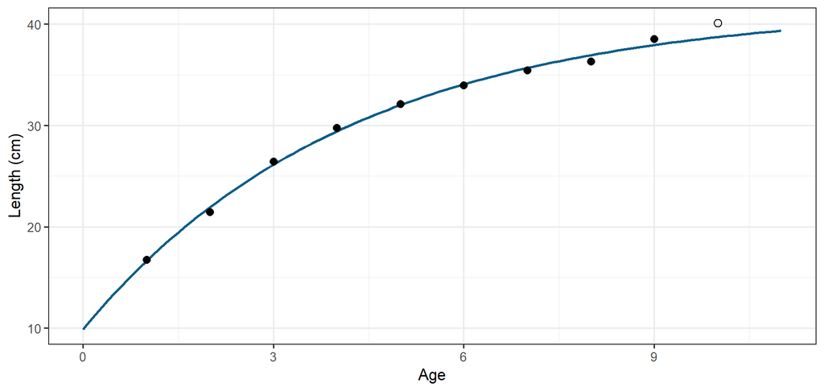

Mean length-at-age implied by ple4 catch weights (points) and the fitted von Bertalanffy curve at mid-year (line). The plus group (open point) is not used in the fit.

```r
vb_age <- seq(0, max(ages) + 1, 0.1)
ggplot() +
  geom_line(aes(vb_age, c(lhpar["linf"]) *
                  (1 - exp(-c(lhpar["k"]) * (vb_age + 0.5 - c(lhpar["t0"]))))),
            colour = "#0b5d8a", linewidth = 0.9) +
  geom_point(aes(ages, l_a, shape = fit_age), size = 2.2) +
  scale_shape_manual(values = c(`TRUE` = 16, `FALSE` = 1), guide = "none") +
  labs(x = "Age", y = "Length (cm)") + theme_bw()
```

**Check.** With ages 1-9 only, $L_\infty$ and $k$ are partly confounded; the fit only needs to reproduce lengths over the ages present in the stock. If you have published growth parameters for the stock, use them directly in `FLPar(linf =, k =, t0 =, a =, b =)` and check them with the plot above.

> **Sex-structured stocks (Doc 2).** `lhpar` will carry a second dimension, `unit = c("F", "M")`, so that `lhpar[, "F"]` lines up with `stk[, , "F"]`. See the last section.

## 2.3 Inverse age-length key

`iALK()` builds $P(l \mid a, t)$: normal length-at-age with $\mathrm{sd} = cv \cdot L(a+t)$, on the grid returned by `len_grid()` (lower bin limits, last bin a plus group). Within-year time $t$ enters as $t_0 - t$. Every downstream helper takes the grid from the gear (`gear$grid`), so it is defined once here.

```r
grid <- list(lmin = 5, lmax_mult = 1.2, bin = 1, cv = 0.1)
lens <- len_grid(c(lhpar["linf"]), grid$lmin, grid$lmax_mult, grid$bin)

ialk <- iALK(params = FLPar(linf = c(lhpar["linf"]), k = c(lhpar["k"]),
                            t0 = c(lhpar["t0"]) - 0.5),
             age = ages, cv = grid$cv, lmin = grid$lmin, bin = grid$bin,
             max = max(lens))
ialk_mat <- matrix(c(ialk), nrow = length(ages),
                   dimnames = list(age = ages, len = lens))
dim(ialk_mat)
```

```
## [1] 10 46
```

```r
# rows are probability distributions
range(rowSums(ialk_mat))
```

```
## [1] 1 1
```

```r
# mean length by age reproduces the growth curve (up to grid truncation)
len_mid  <- lens + grid$bin / 2
mean_len <- c(ialk_mat %*% len_mid)
vb_len   <- c(lhpar["linf"]) * (1 - exp(-c(lhpar["k"]) * (ages + 0.5 - c(lhpar["t0"]))))
round(cbind(age = ages, iALK = mean_len, vonbert = vb_len), 1)
```

```
##       age iALK vonbert
##  [1,]   1 17.1    16.6
##  [2,]   2 22.4    21.9
##  [3,]   3 26.6    26.1
##  [4,]   4 29.9    29.4
##  [5,]   5 32.5    32.0
##  [6,]   6 34.6    34.1
##  [7,]   7 36.2    35.7
##  [8,]   8 37.4    36.9
##  [9,]   9 38.4    37.9
## [10,]  10 39.2    38.7
```

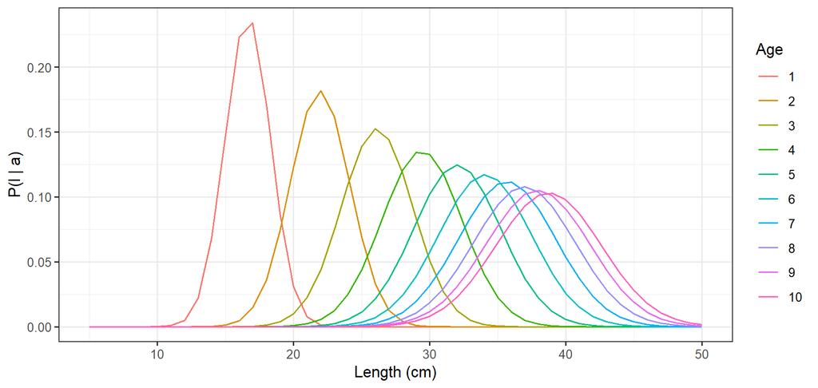

Inverse age-length key P(l | a) at mid-year.

```r
df_ialk <- as.data.frame(as.table(ialk_mat), responseName = "p")
df_ialk$len <- an(as.character(df_ialk$len))
ggplot(df_ialk, aes(len, p, colour = age)) + geom_line() +
  labs(x = "Length (cm)", y = "P(l | a)", colour = "Age") + theme_bw()
```

## 2.4 Gears: one commercial fleet and one survey

Selectivity is specified **in length**, $s_g(l)$, and integrated through the inverse key to give selectivity-at-age and the capture-conditioned key:

$$s_{g,a}=\sum_l P(l\mid a,t)\,s_g(l),\qquad
P(l\mid a,g)=\frac{P(l\mid a,t)\,s_g(l)}{s_{g,a}}.$$

`build_gear()` returns both, the F partition, and the gear’s **sampling design**: `obs` (`"fishery"` or `"survey"`), `timing` and `n_seasons`. The two gears are:

- **Commercial**: the fleet that takes all the catch (`f_mult = 1`), sampled at mid-year (`timing = 0.5`).
- **Survey**: the first-quarter International Bottom Trawl Survey (`ple4.indices$IBTS_Q1`). It removes no catch (`obs = "survey"` implies `f_mult = 0`), so the catch split by gear is `c(Commercial = 1, Survey = 0)`, but it has its own length selectivity, timing and sample size.

### 2.4.1 Target selectivities-at-age from ple4

The length-selectivity parameters are chosen so that $s_{g,a}$ reproduces the age selectivities in the data: the mean exploitation pattern over the last five years for the fleet, and the mean survey selectivity-at-age (`sel.pattern(ple4.indices$IBTS_Q1)`) for the survey. Ages outside the survey age range are left out of the survey fit.

```r
yrs_sel <- ac((maxyr - 4):maxyr)
sel_com <- yearMeans(harvest(ple4)[, yrs_sel])
sel_com <- c(sel_com / max(sel_com))

ibts  <- ple4.indices$IBTS_Q1
srv_t <- mean(range(ibts)[c("startf", "endf")])        # within-year timing (Q1)
if (!is.finite(srv_t)) srv_t <- 1 / 8

# survey selectivity-at-age as estimated in the assessment (sel.pattern)
sp      <- sel.pattern(ibts)
sp_mean <- apply(sp, c(1, 3:6), mean, na.rm = TRUE)
if (all(!is.finite(sp_mean))) {
  # fallback: empirical catchability-at-age, index / numbers at survey time
  yrs_i   <- intersect(dimnames(index(ibts))$year, dimnames(ple4)$year)
  n_i     <- (stock.n(ple4) * exp(-(harvest(ple4) + m(ple4)) * srv_t))[
               dimnames(index(ibts))$age, yrs_i]
  sp_mean <- apply(index(ibts)[, yrs_i] / n_i, c(1, 3:6), mean, na.rm = TRUE)
}
ages_i  <- intersect(dimnames(sp_mean)$age, ac(ages))  # survey ages in the stock
sp_i    <- c(sp_mean[ages_i])
sel_srv <- setNames(rep(NA_real_, length(ages)), ages)
sel_srv[ages_i] <- sp_i / max(sp_i, na.rm = TRUE)

round(rbind(Commercial = sel_com, Survey = sel_srv), 2)
```

```
##               1    2    3    4    5    6    7    8    9   10
## Commercial 0.47 0.76 1.00 0.95 0.77 0.55 0.35 0.20 0.11 0.11
## Survey     0.10 0.54 0.89 1.00 0.96 0.64 0.64 0.64   NA   NA
```

```r
c(survey_timing = srv_t)
```

```
## survey_timing
##     0.1038277
```

### 2.4.2 Fitting length selectivity to the age targets

The helper below is written for this guideline; it may become an FLRef function (`fit_gear_sel()`). It minimises the squared difference between the ALK-integrated $s_{g,a}$ from `build_gear()` and the target, so the fitted length curve is exactly the one the gear object will use.

An unconstrained fit is not enough. Age targets can be matched by unrealistic length curves: a dome in age, for instance, is reproduced almost as well by a near-vertical “cliff” in length, and a survey that catches mostly age 1 by a curve that only declines from the smallest length class. A length selectivity should always have an **ascending limb** and a **gradually curved descending limb**. The double-normal is therefore fitted in a parameterisation that guarantees both:

$$\sigma_L = e^{q_2},\qquad
L_{peak} = l_{min} + 2.5\,\sigma_L + e^{q_1},\qquad
\sigma_R = \sigma_L\,(1 + e^{q_3}).$$

- $L_{peak} \ge l_{min} + 2.5\sigma_L$ means selectivity in the smallest length class is at most $e^{-2.5^2/2} \approx 0.04$: the ascending limb is always inside the length grid.
- $\sigma_R \ge \sigma_L$ means the descending limb is never steeper than the ascending one, so it is a curved dome and not a cliff; large $\sigma_R$ approaches asymptotic (logistic-like) selectivity.
- Bounds keep $\sigma_L$ between `sd_min` and $0.3L_\infty$, and $L_{peak}$ below $L_\infty$.

```r
fit_gear_sel <- function(target, lhpar, age, type = c("dnormal", "logistic"),
                         timing = 0.5, grid, sd_min = 1) {
  type <- match.arg(type)
  ok   <- is.finite(target)
  linf <- c(lhpar["linf"])
  l_at <- linf * (1 - exp(-c(lhpar["k"]) * (age + timing - c(lhpar["t0"]))))

  mk <- function(q) switch(type,
    logistic = list(type = "logistic", L50 = grid$lmin + exp(q[1]),
                    L95 = grid$lmin + exp(q[1]) + exp(q[2])),
    dnormal  = {
      sdl <- exp(q[2])
      list(type = "dnormal", Lpeak = grid$lmin + 2.5 * sdl + exp(q[1]),
           sd_left = sdl, sd_right = sdl * (1 + exp(q[3])))
    })

  sel_a <- function(q) {
    cfg <- c(mk(q), f_mult = 1, ess_age = 1, ess_len = 1)
    g <- build_gear(list(G = cfg), lhpar = lhpar, age = age, timing = timing,
                    lmin = grid$lmin, lmax_mult = grid$lmax_mult,
                    bin = grid$bin, cv = grid$cv)$G
    c(g$sel_a)
  }
  obj <- function(q) sum((sel_a(q)[ok] - target[ok])^2)

  # start: peak at the length of the age with maximum target selectivity
  l_pk <- l_at[ok][which.max(target[ok])]
  if (type == "dnormal") {
    sdl0  <- max(sd_min, 0.15 * l_pk)
    q0    <- c(log(max(l_pk - grid$lmin - 2.5 * sdl0, 1)), log(sdl0), 0)
    lower <- c(log(0.5), log(sd_min), log(0.05))
    upper <- c(log(linf), log(0.3 * linf), log(20))
  } else {
    l50   <- approx(target[ok], l_at[ok], 0.5, ties = mean)$y
    q0    <- c(log(max(l50 - grid$lmin, 1)), log(5))
    lower <- c(log(0.5), log(0.5))
    upper <- c(log(linf), log(0.5 * linf))
  }
  q0  <- pmin(pmax(q0, lower), upper)
  opt <- optim(q0, obj, method = "L-BFGS-B", lower = lower, upper = upper)
  list(cfg = mk(opt$par), sel_a = sel_a(opt$par), ssq = opt$value,
       at_bound = any(abs(opt$par - lower) < 1e-6 | abs(opt$par - upper) < 1e-6))
}

fit_com <- fit_gear_sel(sel_com, lhpar, ages, "dnormal", timing = 0.5, grid = grid)
fit_srv <- fit_gear_sel(sel_srv, lhpar, ages, "dnormal", timing = srv_t, grid = grid)

fit_tab <- function(...) {
  fits <- list(...)
  t(sapply(fits, function(f) c(unlist(f$cfg[-1]), ssq = f$ssq,
                               at_bound = f$at_bound)))
}
round(fit_tab(Commercial = fit_com, Survey = fit_srv), 3)
```

```
##             Lpeak sd_left sd_right   ssq at_bound
## Commercial 26.272   5.994    6.294 0.081        1
## Survey     27.521   5.789    8.053 0.029        0
```

**Check.** `at_bound = 1` means a parameter sits on a bound: the age target asks for a shape the constraints do not allow (typically a very steep dome). That is acceptable when the plots below look reasonable, because the constraint is deliberate; the fitted selectivity-at-age will then only “roughly” match the target at the oldest ages.

### 2.4.3 Building the gear objects

Both gears are built in one call. The survey’s own `timing` overrides the call-level default (mid-year), so its capture-conditioned key is evaluated at the time of the survey. Because the survey has `f_mult = 0`, its F share is zero and the commercial share is one at every age.

```r
build_design <- function(cfg)
  build_gear(cfg, lhpar = lhpar, age = ages, timing = 0.5,
             lmin = grid$lmin, lmax_mult = grid$lmax_mult,
             bin = grid$bin, cv = grid$cv, fbar_range = fbar_r)

om_gears <- build_design(list(
  Commercial = c(fit_com$cfg, f_mult = 1, ess_age = 50, ess_len = 300),
  Survey     = c(fit_srv$cfg, obs = "survey", ess_age = 30, ess_len = 200,
                 timing = srv_t)))

data.frame(obs = gear_par(om_gears, "obs"), f_mult = gear_par(om_gears, "f_mult"),
           timing = sapply(om_gears, function(g) g$grid$timing),
           n_seasons = gear_par(om_gears, "n_seasons"),
           ess_age = gear_par(om_gears, "ess_age"),
           ess_len = gear_par(om_gears, "ess_len"))
```

```
##                obs f_mult    timing n_seasons ess_age ess_len
## Commercial fishery      1 0.5000000         1      50     300
## Survey      survey      0 0.1038277         1      30     200
```

```r
# capture-conditioned keys: rows sum to one; all components share one grid
sapply(om_gears, function(gr) c(
  rowsum_min = min(rowSums(gr$condALK)), rowsum_max = max(rowSums(gr$condALK)),
  length_bins = ncol(gr$condALK),
  same_grid = identical(colnames(gr$condALK), dimnames(gr$sel_len)$len)))
```

```
##             Commercial Survey
## rowsum_min           1      1
## rowsum_max           1      1
## length_bins         46     46
## same_grid            1      1
```

```r
# static F shares: the catch split is c(1, 0) at every age
round(rbind(Commercial = c(om_gears$Commercial$f_share),
            Survey     = c(om_gears$Survey$f_share)), 3)
```

```
##            [,1] [,2] [,3] [,4] [,5] [,6] [,7] [,8] [,9] [,10]
## Commercial    1    1    1    1    1    1    1    1    1     1
## Survey        0    0    0    0    0    0    0    0    0     0
```

```r
# joint selectivity equals the commercial selectivity for a single fishing gear
round(rbind(joint = c(joint_sel(om_gears)),
            commercial = c(om_gears$Commercial$sel_a) /
              max(om_gears$Commercial$sel_a)), 3)
```

```
##             [,1]  [,2] [,3]  [,4]  [,5]  [,6]  [,7]  [,8]  [,9] [,10]
## joint      0.356 0.853    1 0.858 0.655 0.489 0.371 0.291 0.236 0.199
## commercial 0.356 0.853    1 0.858 0.655 0.489 0.371 0.291 0.236 0.199
```

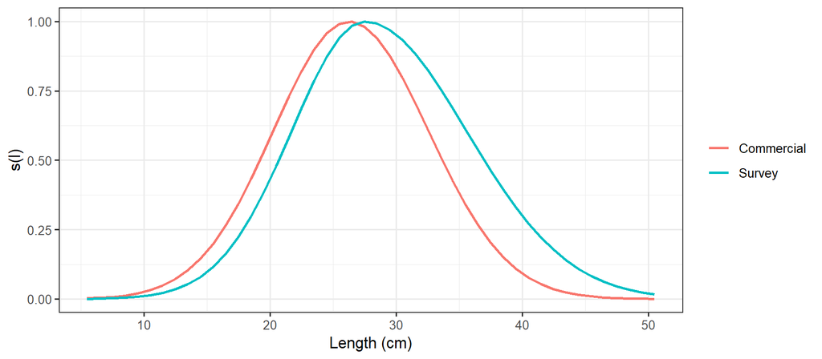

Fitted selectivity-at-length.

```r
df_l <- do.call(rbind, lapply(names(om_gears), function(g)
  data.frame(gear = g, len = om_gears[[g]]$len_bins$mid,
             sel = c(om_gears[[g]]$sel_len))))
ggplot(df_l, aes(len, sel, colour = gear)) + geom_line(linewidth = 0.9) +
  labs(x = "Length (cm)", y = "s(l)", colour = NULL) + theme_bw()
```

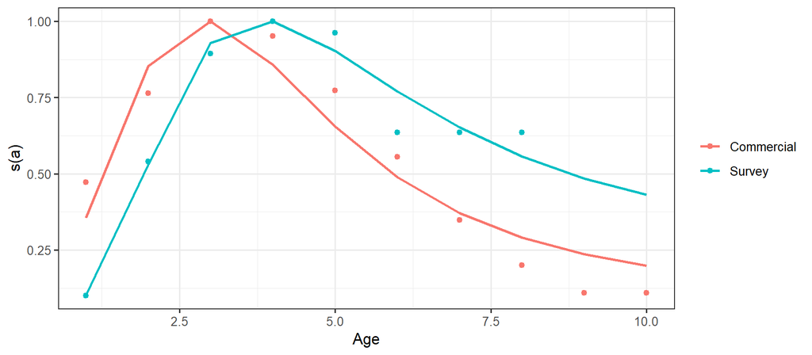

ALK-integrated selectivity-at-age from build_gear() (lines) against the ple4 targets (points).

```r
df_a <- do.call(rbind, lapply(names(om_gears), function(g)
  data.frame(gear = g, age = ages, sel = c(om_gears[[g]]$sel_a),
             target = if (g == "Commercial") sel_com else sel_srv)))
ggplot(df_a, aes(age, sel, colour = gear)) + geom_line(linewidth = 0.9) +
  geom_point(aes(y = target)) +
  labs(x = "Age", y = "s(a)", colour = NULL) + theme_bw()
```

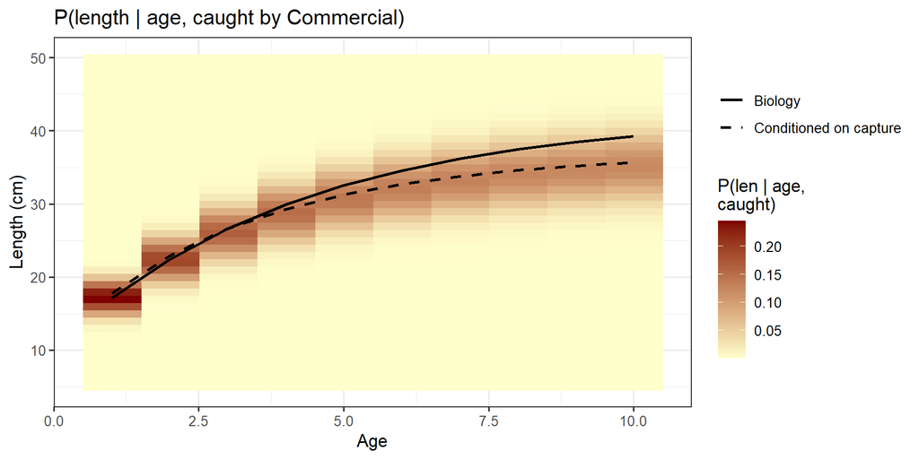

Capture-conditioned key P(l | a, g) for the commercial gear, with mean length-at-age in the population (solid) and in the catch (dashed): young ages are caught at above-average length.

```r
plot_condALK(om_gears$Commercial, params = TRUE)
```

## 2.5 Partitioning the true catch by gear

`catch_n_gear()` is the single definition of gear catch used by the OM and by `sampling.lfd.oem()`:

$$C_{g,a,y}=N_{a,y}\,\frac{\phi_{g,a}F_{a,y}}{Z_{a,y}}\left(1-e^{-Z_{a,y}}\right),
\qquad \sum_g \phi_{g,a}=1 .$$

```r
yrs <- ac((maxyr - 9):maxyr)            # the "data years" used below
cn  <- catch_n_gear(ple4, om_gears, years = yrs)

# catch split by gear, as passed to e.g. FLicc (catch_by_gear)
catch_by_gear(cn, ple4, years = yrs)
```

```
##     gear
## iter Commercial Survey
##    1          1      0
```

```r
# Baranov total vs. catch.n in ple4 (assessment-consistent but not identical)
rel <- attr(cn, "total") / catch.n(ple4)[, yrs]
round(range(rel, na.rm = TRUE), 3)
```

```
## [1] 1 1
```

The survey “catch” is not a removal. What the survey samples is numbers at the time of the survey, weighted by survey selectivity-at-age, $I_{a,y}=N_{a,y}e^{-Z_{a,y}t_s}s_{\mathrm{srv},a}$ (`survey_n_gear()`).

```r
in_srv <- survey_n_gear(ple4, om_gears$Survey, years = yrs)
```

## 2.6 Single-stage length sampling: `len.sim()`

`len.sim()` projects an at-age composition through the key and draws one multinomial length sample of size `ess`. Without a gear it uses the biological key $P(l\mid a)$; with a gear it uses $P(l\mid a,g)$. The difference matters: within an age class the gear selects by length.

```r
set.seed(1)
lfd_bio  <- len.sim(cn$Commercial, params = lhpar, ess = 300, timing = 0.5,
                    bin = grid$bin, cv = grid$cv, lmin = grid$lmin,
                    lmax = grid$lmax_mult)
lfd_gear <- len.sim(cn$Commercial, params = lhpar, ess = 300, timing = 0.5,
                    gear = om_gears$Commercial)

mean_len_lfd <- function(x) c(quantSums(x * an(dimnames(x)$len)) / quantSums(x))
round(rbind(biological_key = mean_len_lfd(lfd_bio),
            gear_key       = mean_len_lfd(lfd_gear)), 1)
```

```
##                [,1] [,2] [,3] [,4] [,5] [,6] [,7] [,8] [,9] [,10]
## biological_key 22.6 23.3 23.2 24.2 25.2 24.8 24.9 24.7 25.7  25.6
## gear_key       23.6 23.5 22.8 24.2 24.5 25.4 24.8 25.4 26.1  25.5
```

## 2.7 Two-stage sampling: `lfd.sim()`

### 2.7.1 Rationale

Fish in a length sample are not independent draws from the catch. They are collected in clusters (hauls, trips, boxes landed at a market), and fish within a cluster are more alike in size and age than fish from different clusters, because each haul or trip fishes a particular place, depth and time where some cohorts dominate. The information in a length composition is therefore governed by the number of clusters more than by the number of fish measured, and the effective sample size (ESS) of a length composition is usually a small fraction of the number of fish measured. A single-stage multinomial with the nominal number of fish makes simulated data far too precise, so an assessment fitted to them shows unrealistically narrow uncertainty, and an MSE built on them is over-optimistic about length-based advice.

`lfd.sim()` generates the clustering from the population structure itself, with a hierarchical two-stage design:

1. **Stage 1 (clusters to ages).** A multinomial **age** sample of size $n_A$ = `ess_age` from the true catch-at-age composition (via `ca.sim()`),
   $$\mathbf{x}\sim\mathrm{Mult}(n_A,\mathbf{p}),\qquad
   p_a=\frac{C_{g,a}}{\sum_{a'}C_{g,a'}},\qquad \hat
   p_a=\frac{x_a}{n_A}.$$
   $n_A$ is the number of effectively independent age draws: roughly the number of sampled clusters times the effective number of distinct fish per cluster.
2. **Stage 2 (fish to lengths).** A multinomial **length** sample of size $n_L$ = `ess_len` from the sampled age composition projected through the capture-conditioned key $K_{a,l}=P(l\mid a,g)$,
   $$\mathbf{y}\sim\mathrm{Mult}(n_L,\hat{\boldsymbol\pi}),\qquad
   \hat\pi_l=\sum_a\hat p_a K_{a,l},\qquad o_l=\frac{y_l}{n_L}.$$

The sample is unbiased, $E[o_l]=\pi_l=\sum_a p_aK_{a,l}$, and its variance follows from the law of total variance:

$$\mathrm{Var}(o_l)=\frac{\pi_l(1-\pi_l)}{n_L}
+\left(1-\frac{1}{n_L}\right)V_l,\qquad
V_l=\mathrm{Var}(\hat\pi_l)=\frac{1}{n_A}\left(\sum_a
p_aK_{a,l}^2-\pi_l^2\right).$$

The first term is the ordinary multinomial noise of measuring $n_L$ fish; the second is the extra (between-cluster) noise from the age stage. Summing over length bins gives the expected effective sample size,

$$ESS=\frac{\sum_l\pi_l(1-\pi_l)}{\sum_l\mathrm{Var}(o_l)} .$$

Three limits help to choose the sample sizes:

- $n_A\to\infty$: $ESS\to n_L$, the single-stage multinomial.
- $n_L\to\infty$: $ESS\to\sum_l\pi_l(1-\pi_l)/\sum_lV_l\ge n_A$. A length bin mixes several ages, which averages out part of the age-stage noise, so the length composition is somewhat more informative than the age sample it came from.
- Ages that do not overlap in length: $ESS\approx(1/n_A+1/n_L)^{-1}$.

In practice `ess_age` is small (tens: the number of hauls or trips) and `ess_len` large (hundreds to thousands of fish), and the realised ESS lies between $n_A$ and $n_L$, closer to $n_A$ when $n_L\gg n_A$. Unlike an overdispersion parameter (e.g. a Dirichlet-multinomial), the age stage makes the ESS respond to the stock and the gear: a catch dominated by one strong year class or a gear with narrow selectivity gives a different ESS for the same `ess_age`, as real sampling programmes do.

**Within-year sampling (Part II).** Each season is an independent two-stage sample with $n_{A,s}$ and $n_{L,s}$ summing to the annual totals. For the pooled annual composition the seasonal variances add with weights $(n_{L,s}/n_L)^2$, so splitting the same totals among seasons leaves the annual ESS roughly unchanged. What continuous sampling changes is the **target**, the year-round catch composition instead of a snapshot (Part II).

```r
lfd_com <- lfd.sim(cn$Commercial, om_gears$Commercial)        # scaled to catch numbers
lfd_srv <- lfd.sim(in_srv,        om_gears$Survey)
```

`sample_lfd_gears()` does the same for a whole gear list in one call, with exactly the code that `sampling.lfd.oem()` runs inside the MSE (raw counts, not scaled):

```r
smp_a <- sample_lfd_gears(ple4, om_gears, years = yrs)
sapply(smp_a$lfd, function(x) range(c(quantSums(x))))   # = ess_len per year
```

```
##      Commercial Survey
## [1,]        300    200
## [2,]        300    200
```

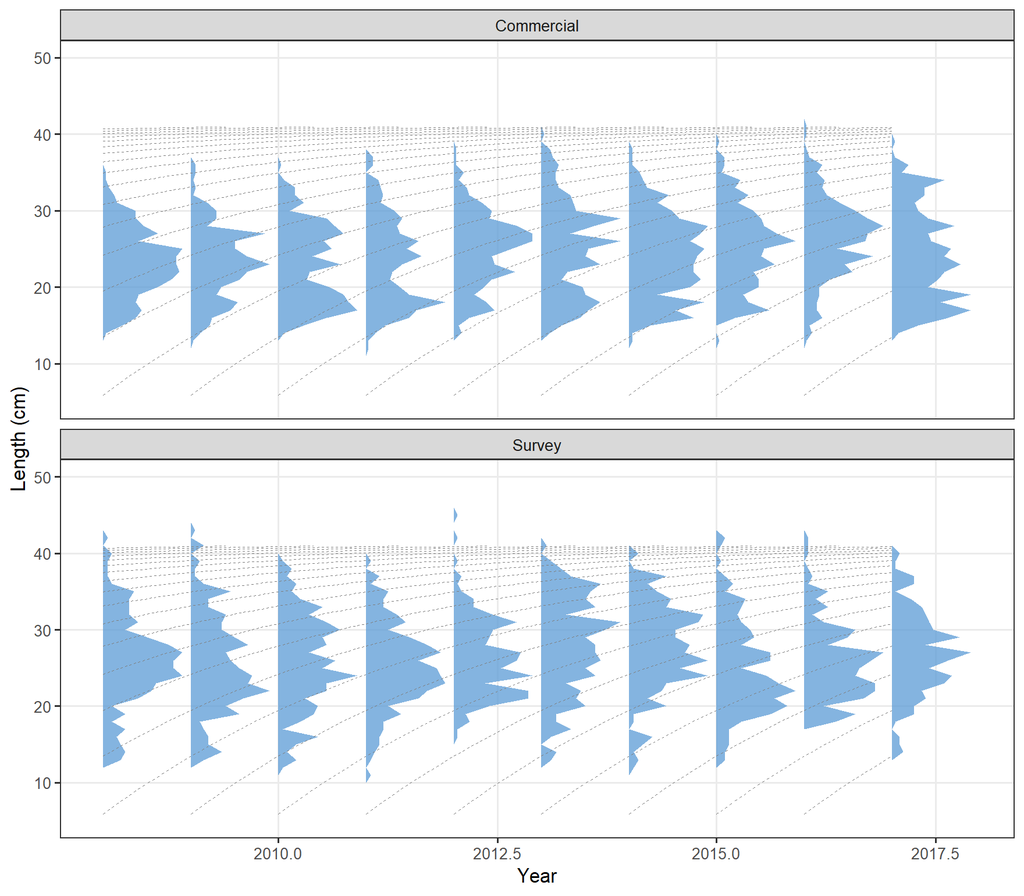

Simulated commercial and survey length samples with von Bertalanffy cohort lines.

```r
plot_lfd_ridgeline(list(Commercial = lfd_com, Survey = lfd_srv), lhpar = lhpar)
```

### 2.7.2 Check: realised effective sample size

For a multinomial sample the McAllister-Ianelli estimator $\widehat{ESS}=\sum_l p_l(1-p_l)\big/\sum_l(o_l-p_l)^2$ recovers the sample size. Replicating one year many times shows that the single-stage sampler returns `ess`, while the two-stage sampler returns an effective sample size well below `ess_len`, which is the intended behaviour.

```r
nrep <- 500
x    <- propagate(cn$Commercial[, ac(maxyr)], nrep)
gC   <- om_gears$Commercial
p_true <- c((c(cn$Commercial[, ac(maxyr)]) / sum(cn$Commercial[, ac(maxyr)])) %*%
              gC$condALK)

ess_mi <- function(lfd, p) {
  if (dim(lfd)[4] > 1) lfd <- seasonSums(lfd)
  o <- matrix(c(lfd), ncol = dims(lfd)$iter)
  o <- sweep(o, 2, colSums(o), "/")
  sum(p * (1 - p)) / colSums((o - p)^2)
}
one <- len.sim(x, params = lhpar, ess = gC$ess_len, timing = 0.5,
               gear = gC, scale = FALSE)
two <- lfd.sim(x, gC, scale = FALSE)

c(ess_len = gC$ess_len, ess_age = gC$ess_age,
  single_stage = median(ess_mi(one, p_true)),
  two_stage    = median(ess_mi(two, p_true)))
```

```
##      ess_len      ess_age single_stage    two_stage
##     300.0000      50.0000     319.8542     220.9882
```

### 2.7.3 Check: theory against simulation

The variance formula gives the expected ESS without simulation. It is compared here with the simulated ESS (as a ratio of means, $\sum_l\pi_l(1-\pi_l)/\overline{\sum_l(o_l-\pi_l)^2}$, which is the quantity the formula predicts) over a range of `ess_age` for `ess_len = 300`.

```r
ess_two_stage <- function(p_a, K, n_A, n_L) {
  p_a <- p_a / sum(p_a)
  pl  <- c(p_a %*% K)
  V   <- (c(p_a %*% K^2) - pl^2) / n_A
  sum(pl * (1 - pl)) / sum(pl * (1 - pl) / n_L + (1 - 1 / n_L) * V)
}
ess_rm <- function(lfd, p) {
  o <- matrix(c(lfd), ncol = dims(lfd)$iter)
  o <- sweep(o, 2, colSums(o), "/")
  sum(p * (1 - p)) / mean(colSums((o - p)^2))
}

p_a0  <- c(cn$Commercial[, ac(maxyr)])
n_Ag  <- c(10, 25, 50, 100, 250, 1000)
ess_g <- t(sapply(n_Ag, function(nA) {
  sim <- lfd.sim(propagate(cn$Commercial[, ac(maxyr)], 300), gC,
                 ess_age = nA, ess_len = 300, scale = FALSE)
  c(ess_age = nA, predicted = ess_two_stage(p_a0, gC$condALK, nA, 300),
    simulated = ess_rm(sim, p_true))
}))
round(ess_g)
```

```
##      ess_age predicted simulated
## [1,]      10        89        93
## [2,]      25       154       152
## [3,]      50       203       197
## [4,]     100       242       247
## [5,]     250       274       273
## [6,]    1000       293       307
```

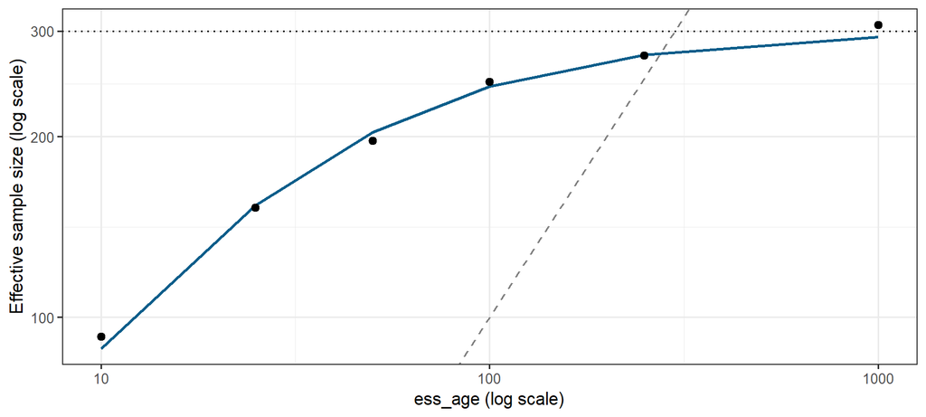

Expected (line) and simulated (points) effective sample size of a two-stage length sample with ess_len = 300 (dotted) as a function of ess_age; the dashed line is the 1:1 line ESS = ess_age.

```r
ggplot(as.data.frame(ess_g), aes(ess_age)) +
  geom_line(aes(y = predicted), colour = "#0b5d8a", linewidth = 0.9) +
  geom_point(aes(y = simulated), size = 2) +
  geom_hline(yintercept = 300, linetype = 3) +
  geom_abline(slope = 1, intercept = 0, linetype = 2, colour = "grey50") +
  scale_x_log10() + scale_y_log10() +
  labs(x = "ess_age (log scale)", y = "Effective sample size (log scale)") +
  theme_bw()
```

### 2.7.4 Why the ESS lies above `ess_age`: the growth curve

The age stage adds $V_l=\mathrm{Var}_{a\sim p}(K_{a,l})/n_A$, the variance across ages of the probability that a fish of age $a$ falls in length class $l$. It is large only when ages put their fish in different length classes. If every length class belonged to a single age, an extra fish of age 3 in the age sample would show up one-to-one in the length composition and $ESS\approx(1/n_A+1/n_L)^{-1}$, on the 1:1 line. If all ages had the same length distribution, age-sampling errors would be invisible in length ($V_l=0$) and $ESS=n_L$.

The von Bertalanffy curve decides where a stock lies between these extremes. The spacing between consecutive ages shrinks geometrically, $\bar L_{a+1}-\bar L_a=(L_\infty-\bar L_a)(1-e^{-k})$, while the spread within an age grows, $\sigma_a=cv\,\bar L_a$. The separation of neighbouring ages, $d_a=(\bar L_{a+1}-\bar L_a)/\sigma_a$, is therefore large for young fish on the steep part of the curve and falls towards zero as $\bar L_a\to L_\infty$. Age-sampling noise among young, well-separated ages passes through to the length composition. Among old ages piled up near $L_\infty$ it largely cancels: too many age-8 and too few age-9 fish hardly change the length composition. The more of the catch lies on the flat part of the curve (slow growth, small $k$, large CV, a gear that cuts out the young ages), the further the ESS rises above `ess_age`. The flip side is the backward check below: where ages overlap in length, the length composition cannot tell them apart, so ALK errors are largest at the oldest ages.

```r
K   <- gC$condALK
ovl <- sapply(seq_len(nrow(K) - 1), function(i) sum(pmin(K[i, ], K[i + 1, ])))
sep <- data.frame(
  ages        = paste(ages[-length(ages)], ages[-1], sep = "-"),
  mean_length = round(mean_len[-length(ages)], 1),
  spacing     = round(diff(mean_len), 1),                     # cm between ages
  d           = round(diff(mean_len) / (grid$cv * mean_len[-length(ages)]), 2),
  overlap     = round(ovl, 2),                                # shared length mass
  catch_share = round(p_a0[-length(ages)] / sum(p_a0), 2))
sep
```

```
##   ages mean_length spacing    d overlap catch_share
## 1  1-2        17.1     5.3 3.10    0.16        0.18
## 2  2-3        22.4     4.2 1.86    0.40        0.22
## 3  3-4        26.6     3.3 1.24    0.59        0.17
## 4  4-5        29.9     2.6 0.87    0.72        0.20
## 5  5-6        32.5     2.0 0.63    0.80        0.12
## 6  6-7        34.6     1.6 0.47    0.86        0.06
## 7  7-8        36.2     1.3 0.35    0.90        0.03
## 8  8-9        37.4     1.0 0.27    0.92        0.01
## 9 9-10        38.4     0.8 0.20    0.94        0.00
```

`d` is the separation of neighbouring ages in standard deviations of length, `overlap` the probability mass the two capture-conditioned length distributions share (0 = separate, 1 = identical), and `catch_share` the share of the younger age in the catch. Ages with a large catch share and high overlap are the ones that lift the ESS above `ess_age`.

### 2.7.5 Check: common random numbers

Inside an MSE each management procedure must see the same sampling noise. `rUnif_lfd()` pre-generates the uniforms for both stages and `rmultinom_crn()` turns them into multinomial draws. Same deviates give the same sample; a small change in the catch moves only a few fish between neighbouring bins.

```r
u <- rUnif_lfd(om_gears, years = yrs, nsim = 1, seed = 456)
s1 <- lfd.sim(cn$Commercial, gC, u_age = u$age$Commercial, u_len = u$len$Commercial,
              scale = FALSE)
s2 <- lfd.sim(cn$Commercial, gC, u_age = u$age$Commercial, u_len = u$len$Commercial,
              scale = FALSE)
identical(s1, s2)
```

```
## [1] TRUE
```

```r
cn_pert <- cn$Commercial
cn_pert[1, ] <- cn_pert[1, ] * 1.05          # 5% more age-1 fish
s3 <- lfd.sim(cn_pert, gC, u_age = u$age$Commercial, u_len = u$len$Commercial,
              scale = FALSE)
c(fish_moved_per_year = mean(c(quantSums(abs(s3 - s1)))) / 2,
  sample_size = gC$ess_len)
```

```
## fish_moved_per_year         sample_size
##                 5.8               300.0
```

## 2.8 Backward check: from length samples back to catch-at-age

A forward simulator should pass a backward test: if an assessment converts the simulated length samples back to ages with an age-length key (ALK), it should recover the OM catch-at-age (`catch.n`), apart from sampling error. This also shows which part of the error comes from the length sample and which from the ALK.

For gear $g$, year $y$ and length class $l$, the ALK is the distribution of age given length in the catch,

$$P(a\mid l,g)=\frac{C_{g,a}\,P(l\mid
a,g)}{\sum_{a'}C_{g,a'}\,P(l\mid a',g)},$$

and the catch-at-age estimate from a length sample $n_l$ is $\hat n_a=\sum_l n_l\,P(a\mid l,g)$, raised to the gear’s catch weight by sum of products, $\tilde n_a=\hat n_a\,C^{w}_{g}\big/\sum_{a'}\hat n_{a'}w_{a'}$. Two estimates are compared with the true gear catch-at-age $C_{g,a,y}$ (`catch_n_gear()`), all raised in the same way:

| Estimate | Data | Errors included |
| --- | --- | --- |
| **True ALK** | two-stage LFD $\times$ exact $P(a\mid l,g)$ | length sampling |
| **Sampled ALK** | two-stage LFD $\times$ ALK from a length-stratified otolith subsample (`alk.sample()`, at most `nbin` fish per length class) | length sampling + ALK sampling: the realistic case |

The key must be the capture-conditioned one: the gear selects by length within an age class, so young ages are caught at above-average length (see the capture-conditioned key above), and a key built from the biological $P(l\mid a)$ would assign these fish to older ages.

```r
as_flpar <- function(m) FLPar(array(m, dim = c(dim(m), 1)),
                              dimnames = list(age = rownames(m), len = colnames(m),
                                              iter = 1))
raise_sop <- function(x, cw, wt) x %*% (cw / quantSums(x * wt))
col_bc <- c(True = "black", `True ALK` = "#0072B2", `Sampled ALK` = "#CC3311")

cn_true  <- cn$Commercial                              # true gear catch-at-age
cw_true  <- catch_gear(cn, ple4)$Commercial            # true gear catch weight
wt_c     <- catch.wt(ple4)[, yrs]
alk_true <- ALKs(cn_true, as_flpar(gC$condALK))         # P(a | l, g), by year

back_calc <- function(seed, nbin = 20) {
  set.seed(seed)
  lfd <- lfd.sim(cn_true, gC, scale = FALSE)            # two-stage length sample
  alk_obs <- alk.sample(lfd, alk_true, nbin = nbin)     # otolith subsample
  est <- list(
    `True ALK`          = applyALK(lfd, alk_true),
    `Sampled ALK`       = applyALK(lfd, alk_obs))
  out <- FLQuants(lapply(est, function(x) {
    x <- FLQuant(c(x), dimnames = dimnames(cn_true))   # common dimnames
    raise_sop(x, cw_true, wt_c)
  }))
  attr(out, "otoliths") <- sum(sapply(alk_obs, sum))
  out
}

bc1 <- back_calc(1)
c(otoliths_per_year = attr(bc1, "otoliths") / length(yrs),
  fish_measured_per_year = gC$ess_len)
```

```
##      otoliths_per_year fish_measured_per_year
##                  280.6                  300.0
```

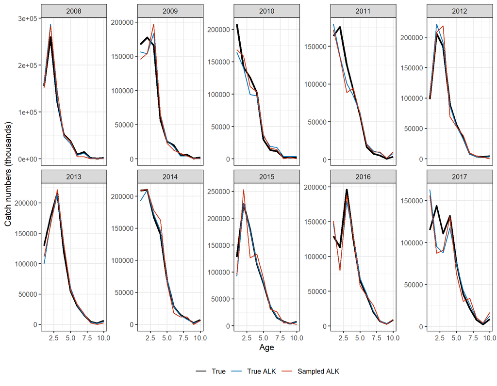

Backward check for one replicate: catch-at-age reconstructed from the simulated commercial length samples, by year, against the true gear catch-at-age (black).

```r
df_bc <- as.data.frame(FLQuants(c(list(True = cn_true), as.list(bc1))))
df_bc$qname <- factor(df_bc$qname, levels = c("True", names(bc1)))
ggplot(df_bc, aes(age, data, colour = qname, linewidth = qname == "True")) +
  geom_line() +
  scale_linewidth_manual(values = c(`TRUE` = 1.1, `FALSE` = 0.6), guide = "none") +
  scale_colour_manual(values = col_bc) +
  facet_wrap(~year, ncol = 5, scales = "free_y") +
  labs(x = "Age", y = "Catch numbers (thousands)", colour = NULL) +
  theme_bw() + theme(legend.position = "bottom")
```

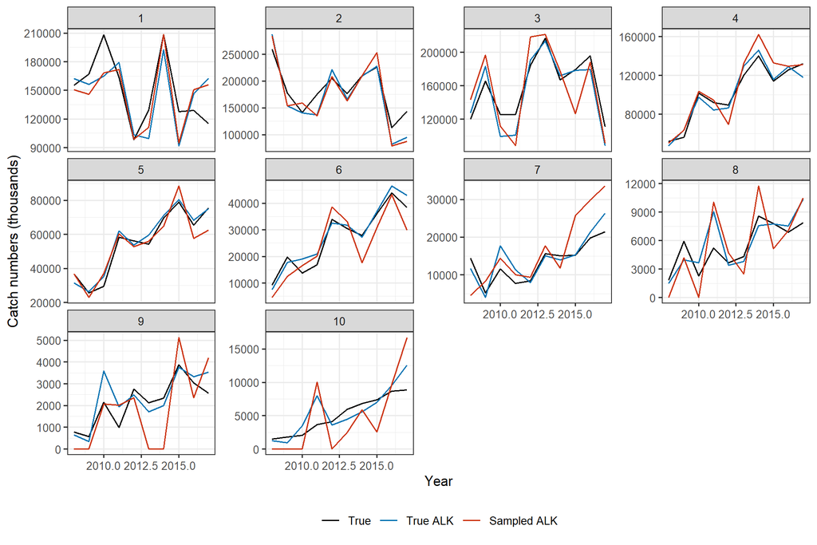

Backward check for one replicate: time series by age.

```r
ggplot(df_bc, aes(year, data, colour = qname)) +
  geom_line() +
  scale_colour_manual(values = col_bc) +
  facet_wrap(~age, scales = "free_y") +
  labs(x = "Year", y = "Catch numbers (thousands)", colour = NULL) +
  theme_bw() + theme(legend.position = "bottom")
```

Replicating the whole sampling chain separates bias (a shifted median) from noise (a wide interval):

```r
nrep_bc <- 50
bc <- lapply(seq_len(nrep_bc), back_calc)

rel_err <- do.call(rbind, lapply(seq_along(bc), function(r)
  do.call(rbind, lapply(names(bc[[r]]), function(m) {
    d <- as.data.frame((bc[[r]][[m]] - cn_true) / cn_true)
    data.frame(rep = r, method = m, age = d$age, year = d$year, rel = d$data)
  }))))
rel_err$method <- factor(rel_err$method, levels = names(bc1))

# median relative error (bias) and median absolute relative error (precision)
tab_bc <- aggregate(rel ~ method + age, rel_err, function(x)
  c(bias = median(x), mare = median(abs(x))))
tab_bc <- do.call(data.frame, tab_bc)
round(xtabs(rel.bias ~ method + age, tab_bc), 2)
```

```
##              age
## method            1     2     3     4     5     6     7     8     9    10
##   True ALK    -0.02 -0.01  0.00  0.00 -0.01  0.00 -0.01 -0.02 -0.03 -0.05
##   Sampled ALK -0.02  0.01  0.02  0.00  0.00 -0.03 -0.06 -0.14 -1.00 -0.27
```

```r
round(xtabs(rel.mare ~ method + age, tab_bc), 2)
```

```
##              age
## method           1    2    3    4    5    6    7    8    9   10
##   True ALK    0.21 0.13 0.07 0.05 0.07 0.10 0.14 0.18 0.21 0.24
##   Sampled ALK 0.20 0.14 0.10 0.11 0.15 0.22 0.32 0.46 1.00 0.55
```

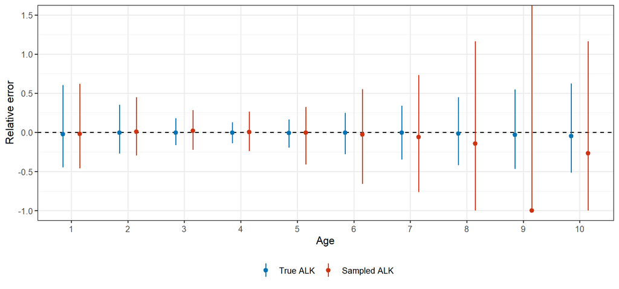

Relative error of the reconstructed catch-at-age over 50 replicates and 10 years: median (point) and 5-95% range (bar). A median away from zero is bias; the bar width is sampling noise.

```r
q_bc <- aggregate(rel ~ method + age, rel_err, quantile, probs = c(0.05, 0.5, 0.95))
q_bc <- do.call(data.frame, q_bc)
names(q_bc)[3:5] <- c("lo", "med", "hi")
ggplot(q_bc, aes(factor(age), med, colour = method)) +
  geom_hline(yintercept = 0, linetype = 2) +
  geom_pointrange(aes(ymin = lo, ymax = hi), position = position_dodge(0.6),
                  size = 0.3) +
  scale_colour_manual(values = col_bc[-1]) +
  coord_cartesian(ylim = c(-1, 1.5)) +
  labs(x = "Age", y = "Relative error", colour = NULL) +
  theme_bw() + theme(legend.position = "bottom")
```

What to look for:

- **True ALK** should be unbiased at all ages; its noise is the length-sample noise, i.e. the two-stage ESS, propagated to ages.
- **Sampled ALK** adds noise mainly at the oldest ages, where few large fish are available for otoliths, and some bias where length classes receive one or no otoliths (those fish are dropped before raising).

`ALKs()` is used with one iteration here; for several iterations see the developer notes.

## 2.9 Raising length samples to catch weight

`lfd_sop()` is the length analogue of `sops()`: it scales each sample so that its sum of products with weight-at-length, $W(l)=a\bar l^{\,b}$, equals the catch weight.

```r
cw         <- catch_gear(cn, ple4)$Commercial
lfd_raised <- lfd_sop(lfd_com, gC, cw)

w <- lfd_raised
w[] <- gC$wt_len[dimnames(lfd_raised)$len]
# by construction, the raised SOP equals the catch weight
round(c(quantSums(lfd_raised * w) / cw), 6)
```

```
##  [1] 1 1 1 1 1 1 1 1 1 1
```

```r
# diagnostic: raised numbers / true catch numbers. Departures from one
#     measure the mismatch between W(l), the growth curve and catch.wt
round(c(quantSums(lfd_raised) / quantSums(cn$Commercial)), 3)
```

```
##  [1] 1.132 1.199 1.216 1.138 1.026 0.933 0.934 0.875 0.816 1.040
```

# 3 Part II: within-year sampling, pulse survey and continuous fishery sampling

## 3.1 Why the sampling time matters

Part I measured all commercial fish at one moment, mid-year. Fishery sampling programmes do not work like that: market and on-board samples are taken throughout the year, and the annual length composition is the pool of many small samples. Two things change within the year and are lost in a single mid-year sample:

1. **Growth.** Each cohort grows during the year, so a cohort sampled in January is shorter than the same cohort in December. Pooling samples over the year smears each cohort mode over its within-year growth increment.
2. **Depletion.** Under constant F and M, more of the annual catch is taken early in the year, when numbers are highest, and the age composition of the catch shifts towards younger fish as older cohorts are fished down.

A survey, in contrast, is a **pulse**: all fish are measured within a few weeks. Placed in January, it samples every cohort at nearly the same point of its growth curve, before the growing season, so the cohort modes of young ages are sharp. Combining a pulse survey with continuous fishery sampling is a common data situation, and a seasonal assessment (e.g. FLicc with seasonal transitions) can only exploit it if the samples keep their timing.

The annual OM in FLRef does not need seasons for this. The observation model splits the annual gear catch-at-age into $S$ equal seasons (next section) and draws an independent two-stage sample in each season, with the conditional key at the season mid-point $(s-0.5)/S$. The annual `ess_age` and `ess_len` are split among seasons, so a monthly design with `ess_age = 200`, `ess_len = 1000` measures about 83 fish a month from about 17 independent clusters: high length sample size, moderate age (cluster) sample size.

## 3.2 How the annual stock is seasonalised

The operating model stays annual: `stock.n`, `harvest` and `m` are annual and the annual catch is the Baranov catch. Seasons exist only on the observation side, which is why any annual `FLom` can be sampled monthly.

### 3.2.1 Within-year dynamics

Within year $y$, let $t\in[0,1)$ be the time since 1 January, with ages incremented on 1 January (the “birthday”) and recruitment entering at $t=0$. With constant instantaneous rates $F_{a}$ and $M_{a}$ during the year, $Z_a=F_a+M_a$ (year index dropped),

$$N_a(t)=N_a(0)\,e^{-Z_a t},\qquad
\frac{dC_{g,a}}{dt}=F_{g,a}\,N_a(t),\qquad F_{g,a}=\phi_{g,a}F_a .$$

The catch of gear $g$ between $t_1$ and $t_2$ is

$$C_{g,a}(t_1,t_2)=\frac{F_{g,a}}{Z_a}\,N_a(0)\left(e^{-Z_at_1}-e^{-Z_at_2}\right),$$

which for $(t_1,t_2)=(0,1)$ is the annual Baranov catch of `catch_n_gear()`. For $S$ equal seasons, season $s$ is $[(s-1)/S,\,s/S)$ and

$$C_{g,a,s}=C_{g,a}\,\pi_{a,s},\qquad
\pi_{a,s}=\frac{e^{-Z_a(s-1)/S}\left(1-e^{-Z_a/S}\right)}{1-e^{-Z_a}},
\qquad \sum_{s=1}^{S}\pi_{a,s}=1$$

($\pi_{a,s}=1/S$ when $Z_a=0$). This is `season_fraction()`. Because the gear shares $\phi_{g,a}$ are constant within the year, $\pi$ is the same for every gear, and the seasonal catches sum exactly to the annual catch. Older, heavily fished ages (high $Z$) have their catch concentrated early in the year.

### 3.2.2 Within-year growth and the seasonal key

Fish caught in season $s$ are assigned the length distribution at the season mid-point $t_s=(s-0.5)/S$:

$$\bar L_a(t_s)=L_\infty\left(1-e^{-k(a+t_s-t_0)}\right),\qquad
P(l\mid a,t_s)=\text{iALK with } t_0\to t_0-t_s,$$

and conditioned on the (time-invariant) length selectivity of the gear, $K_{a,l}(t_s)=P(l\mid a,t_s)s_g(l)\big/\sum_{l'}P(l'\mid a,t_s)s_g(l')$. The expected length composition of the season-$s$ catch and of the year-round catch are

$$\pi_{l,s}=\frac{\sum_aC_{g,a,s}K_{a,l}(t_s)}{\sum_aC_{g,a,s}},\qquad
\pi_l^{\text{year}}=\frac{\sum_s\sum_aC_{g,a,s}K_{a,l}(t_s)}{\sum_aC_{g,a}}
\;\xrightarrow{S\to\infty}\;
\frac{\int_0^1\sum_a\frac{dC_{g,a}}{dt}K_{a,l}(t)\,dt}{\sum_aC_{g,a}} .$$

A single annual sample at $t=0.5$ targets $\sum_aC_{g,a}K_{a,l}(0.5)$ instead, which differs from $\pi_l^{\text{year}}$ through both growth ($K$ changes with $t$) and depletion ($C$ is front-loaded).

### 3.2.3 Assumptions and their limits

- Constant F and M within the year: no seasonal fishing pattern. A seasonal effort profile would replace $F_a$ by $F_ae_s$ with $\sum_se_s/S=1$; this is not implemented yet.
- Growth is evaluated at the season mid-point; within-season growth is ignored (about one month of growth for monthly sampling).
- Birthday and recruitment on 1 January, consistent with the annual OM.
- The plus group is treated like any other age (its length distribution is that of the plus-group age).

### 3.2.4 FLRef functions for seasonalisation

| Function | What it does |
| --- | --- |
| `season_fraction(stock, n_seasons)` | $\pi_{a,y,s}$; multiply annual gear catch-at-age to get seasonal catch-at-age (observation side) |
| `seasonalize_catch_n_gear(stock, f_age_gear, n_seasons)` | the same seasonal catches computed directly from gear F-at-age |
| `pop_n_season(stock, n_seasons)` | numbers-at-age at the start of each season, $N_a(0)e^{-Z_a(s-1)/S}$ |
| `survey_n_gear(stock, gear, timing)` | survey numbers-at-age at any time $t$, $N_a(0)e^{-Z_at}s_{g,a}$ |
| `lfd.sim.season()` | independent two-stage sample per season, key at $t_s$ |
| `sel_a_seasonal_avg()`, `wt_a_seasonal()`, `plot_sel_a_seasonal()` | selectivity- and weight-at-age implied by within-year growth, by season and averaged |

### 3.2.5 Seasonal catch-at-age

```r
fr12 <- season_fraction(ple4[, yrs], 12)
range(seasonSums(fr12))                                 # fractions sum to one
```

```
## [1] 1 1
```

```r
cn_m <- cn$Commercial %*% fr12                          # monthly catch-at-age
range(seasonSums(cn_m) / cn$Commercial, na.rm = TRUE)   # = annual catch
```

```
## [1] 1 1
```

```r
# same result from gear F-at-age with seasonalize_catch_n_gear()
F_g <- harvest(ple4)[, yrs]
phi <- F_g; phi[] <- c(gC$f_share)
cn_m2 <- seasonalize_catch_n_gear(ple4[, yrs], list(Commercial = F_g * phi),
                                  n_seasons = 12)$Commercial
range(cn_m2 / cn_m, na.rm = TRUE)
```

```
## [1] 1 1
```

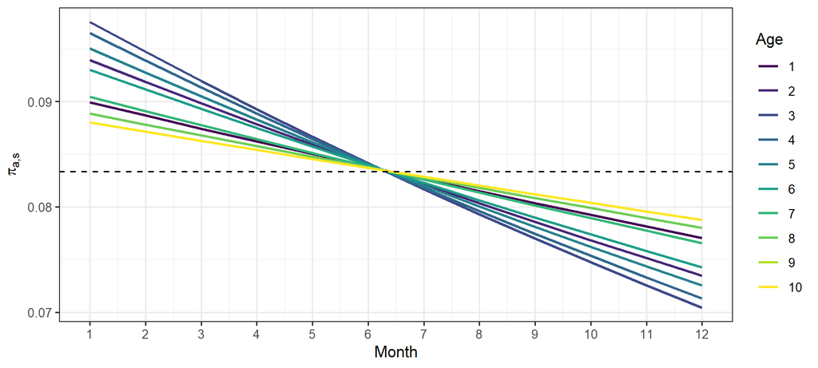

Fraction of the annual catch taken in each month by age in the last year: ages with high total mortality are caught earlier in the year.

```r
df_fr <- as.data.frame(fr12[, ac(maxyr)])
df_fr$season <- as.numeric(as.character(df_fr$season))
ggplot(df_fr, aes(season, data, colour = factor(age))) + geom_line(linewidth = 0.8) +
  geom_hline(yintercept = 1 / 12, linetype = 2) +
  scale_colour_viridis_d(name = "Age") +
  scale_x_continuous(breaks = 1:12) +
  labs(x = "Month", y = expression(pi[a*","*s])) + theme_bw()
```

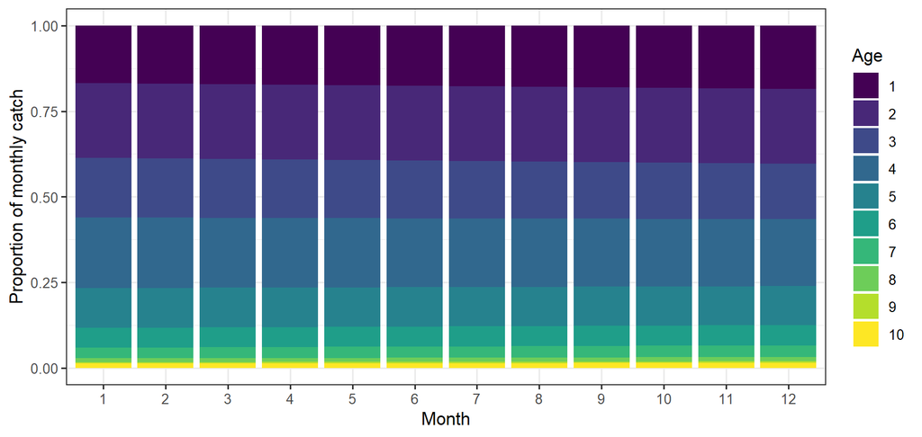

```r
df_m <- as.data.frame(cn_m[, ac(maxyr)])
df_m$season <- factor(as.numeric(as.character(df_m$season)))
ggplot(df_m, aes(season, data, fill = factor(age))) +
  geom_col(position = "fill") +
  scale_fill_viridis_d(name = "Age") +
  labs(x = "Month", y = "Proportion of monthly catch") + theme_bw()
```

## 3.3 Three sampling designs

The fleet and its length selectivity are the same in all designs; only the sampling resolution `n_seasons` changes. The total sample sizes are the same (`ess_age = 200`, `ess_len = 1000` per year), so differences between designs come from **when** fish are measured, not how many. The IBTS-Q1 survey is treated as a pulse in mid-January ($t = 1/24$) instead of the mid-point of its Q1 window; its length selectivity is refitted at that timing so that it keeps the same selectivity-at-age.

```r
srv_jan  <- 1 / 24
fit_srvJ <- fit_gear_sel(sel_srv, lhpar, ages, "dnormal", timing = srv_jan,
                         grid = grid)

design <- function(n_seasons, ess_age = 200, ess_len = 1000)
  build_design(list(
    Commercial = c(fit_com$cfg, f_mult = 1, ess_age = ess_age,
                   ess_len = ess_len, n_seasons = n_seasons),
    Survey     = c(fit_srvJ$cfg, obs = "survey", ess_age = 250, ess_len = 350,
                   timing = srv_jan)))

designs <- list(Annual = design(1), Quarterly = design(4), Monthly = design(12))

# per-season sample sizes of the commercial gear
lapply(designs, function(d) with(d$Commercial,
  rbind(ess_age = split_ess(ess_age, n_seasons),
        ess_len = split_ess(ess_len, n_seasons))))
```

```
## $Annual
##         [,1]
## ess_age  200
## ess_len 1000
##
## $Quarterly
##         [,1] [,2] [,3] [,4]
## ess_age   50   50   50   50
## ess_len  250  250  250  250
##
## $Monthly
##         [,1] [,2] [,3] [,4] [,5] [,6] [,7] [,8] [,9] [,10] [,11] [,12]
## ess_age   17   17   17   17   17   17   17   17   16    16    16    16
## ess_len   84   84   84   84   83   83   83   83   83    83    83    83
```

## 3.4 Expected annual length composition of the catch

Before sampling, compare the **expected** length composition each design targets. The year-round catch composition is computed with a fine (weekly) split; the annual design targets the mid-year snapshot instead.

```r
sel_vec <- function(g) setNames(c(g$sel_len), dimnames(g$sel_len)$len)
expected_lfd <- function(cn_y, stk_y, gear, S) {
  xs <- cn_y %*% season_fraction(stk_y, S)
  p <- 0
  for (s in seq_len(S)) {
    K <- condition_alk(gear_ialk(gear, timing = (s - 0.5) / S), sel_vec(gear))
    p <- p + c(c(xs[, , , s]) %*% K)
  }
  setNames(p / sum(p), colnames(gear$condALK))
}

yr <- ac(maxyr)
gM <- designs$Monthly$Commercial
p_exp <- lapply(c(Annual = 1, Quarterly = 4, Monthly = 12, `Year-round` = 52),
                function(S) expected_lfd(cn$Commercial[, yr], ple4[, yr], gM, S))
len_mid_g <- an(names(p_exp[[1]])) + grid$bin / 2
round(sapply(p_exp, function(p) c(mean_length = sum(p * len_mid_g),
                                  sd_length = sqrt(sum(p * len_mid_g^2) -
                                                   sum(p * len_mid_g)^2))), 2)
```

```
##             Annual Quarterly Monthly Year-round
## mean_length  26.16     26.05   26.04      26.04
## sd_length     5.68      5.80    5.81       5.81
```

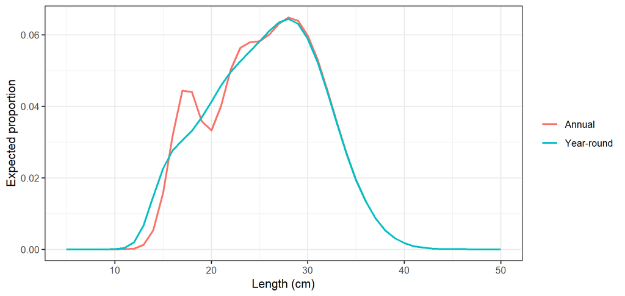

Expected annual length composition of the commercial catch: mid-year snapshot (annual design) against the year-round composition. The year-round composition is broader because each cohort grows during the year.

```r
df_e <- do.call(rbind, lapply(c("Annual", "Year-round"), function(d)
  data.frame(design = d, len = an(names(p_exp[[d]])), p = p_exp[[d]])))
ggplot(df_e, aes(len, p, colour = design)) + geom_line(linewidth = 0.9) +
  labs(x = "Length (cm)", y = "Expected proportion", colour = NULL) + theme_bw()
```

## 3.5 Simulating the designs: `season = FALSE` and `season = TRUE`

`sample_lfd_gears()` reads the design from each gear. With `season = FALSE` (default) the seasonal samples are pooled into one annual sample with `seasonSums()`; with `season = TRUE` they stay in the season dimension. With the same common random numbers, the two are the same sample:

```r
sim_y <- ac((maxyr - 4):maxyr)
u_des <- lapply(designs, rUnif_lfd, years = sim_y, nsim = 1, seed = 99)

s_F <- Map(function(d, u) sample_lfd_gears(ple4, d, sim_y, u_lfd = u),
           designs, u_des)
s_T <- sample_lfd_gears(ple4, designs$Monthly, sim_y, u_lfd = u_des$Monthly,
                        season = TRUE)

dim(s_F$Monthly$lfd$Commercial)   # pooled: one season
```

```
## [1] 46  5  1  1  1  1
```

```r
dim(s_T$lfd$Commercial)           # 12 months
```

```
## [1] 46  5  1 12  1  1
```

```r
identical(c(seasonSums(s_T$lfd$Commercial)), c(s_F$Monthly$lfd$Commercial))
```

```
## [1] TRUE
```

```r
# fish measured per month (ess_len split among months)
c(seasonSums(quantSums(s_T$lfd$Commercial))[, yr]) ; c(quantSums(s_T$lfd$Commercial)[, yr])
```

```
## [1] 1000
```

```
##  [1] 84 84 84 84 83 83 83 83 83 83 83 83
```

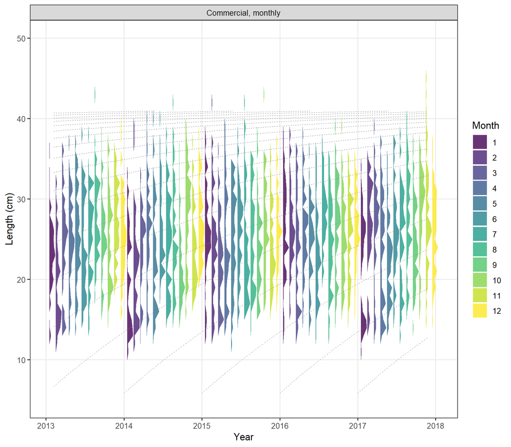

Monthly commercial length samples (season = TRUE) over the last five years, with von Bertalanffy cohort lines: the cohort modes move up the length axis through the year.

```r
plot_lfd_ridgeline(list(`Commercial, monthly` = s_T$lfd$Commercial), lhpar = lhpar)
```

With twelve ridges a year the monthly panel is dense. The quarterly design shows the same within-year progression more clearly: within each year the cohort modes move up from quarter 1 to quarter 4, and the next year’s first quarter starts again from the lower lengths of the following age.

```r
s_Q <- sample_lfd_gears(ple4, designs$Quarterly, sim_y, u_lfd = u_des$Quarterly,
                        season = TRUE)
dim(s_Q$lfd$Commercial)           # 4 quarters
```

```
## [1] 46  5  1  4  1  1
```

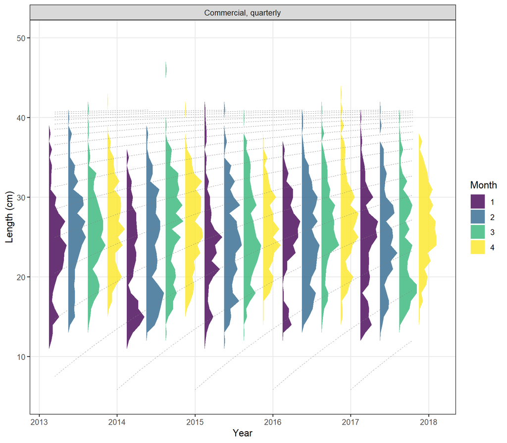

Quarterly commercial length samples (season = TRUE) over the last five years, with von Bertalanffy cohort lines.

```r
plot_lfd_ridgeline(list(`Commercial, quarterly` = s_Q$lfd$Commercial), lhpar = lhpar)
```

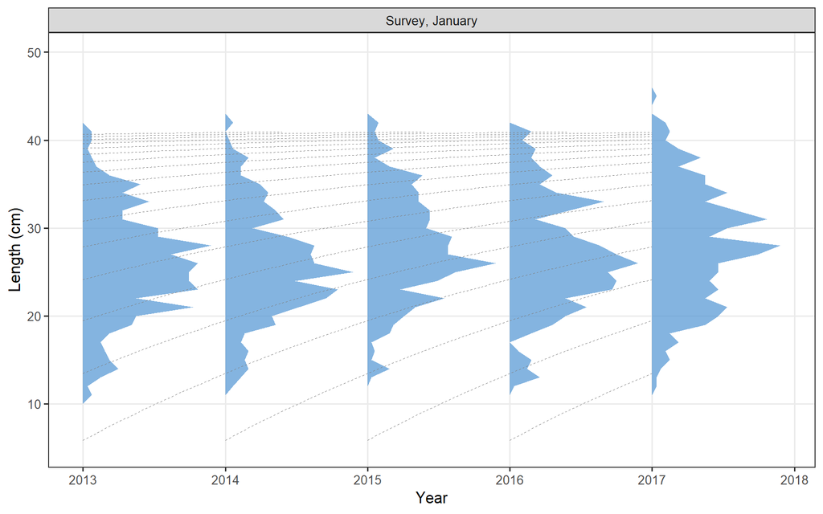

January survey samples: each cohort is measured at the same point of its growth curve, giving sharp modes for the young ages.

```r
plot_lfd_ridgeline(list(`Survey, January` = s_T$lfd$Survey), lhpar = lhpar)
```

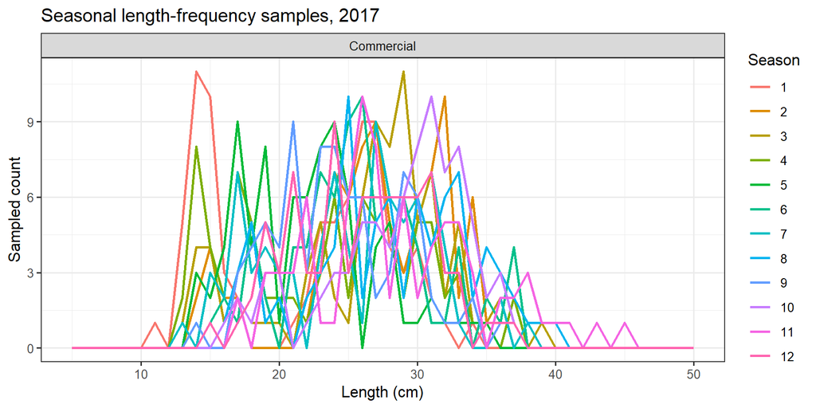

Monthly commercial samples in the last year (season = TRUE).

```r
plot_lfd_season(list(Commercial = s_T$lfd$Commercial), year = maxyr)
```

## 3.6 Contrasting annual and continuous sampling

The pooled annual samples of the three designs, against the year-round expected composition:

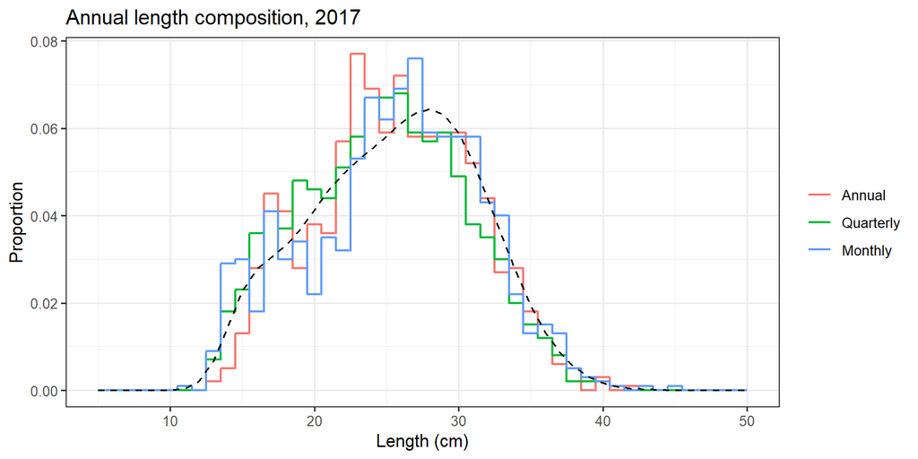

Annual commercial length samples under the three designs (same total sample size) and the expected year-round composition (dashed).

```r
plot_lfd_designs(lapply(s_F, function(s) s$lfd$Commercial), year = maxyr,
                 expected = p_exp$`Year-round`)
```

The replicated effective sample size makes the contrast quantitative. Each design is evaluated against two targets: its **own** expectation (precision) and the **year-round** composition (what the fishery actually caught). A sample that is precise for the wrong target has a high ESS against its own expectation but a lower one against the year-round composition, because the systematic difference does not shrink with sample size.

```r
nrep    <- 200
stk_rep <- propagate(ple4[, yr], nrep)
ess_tab <- sapply(names(designs), function(d) {
  S <- designs[[d]]$Commercial$n_seasons
  x <- sample_lfd_gears(stk_rep, designs[[d]], yr)$lfd$Commercial
  c(own_expectation = median(ess_mi(x, p_exp[[d]])),
    year_round      = median(ess_mi(x, p_exp$`Year-round`)))
})
round(ess_tab)
```

```
##                 Annual Quarterly Monthly
## own_expectation    726       770     763
## year_round         495       768     762
```

# 4 Part III: length sampling inside an MSE with `sampling.lfd.oem()`

`sampling.lfd.oem()` is an `FLoem` method with the same structure as `mse::sampling.oem()`. For each data year it calls `sample_lfd_gears()` on the OM stock (by unit) and reports catch weight by fishery gear. The samples reach the estimator as attributes of the observed stock, `attr(stk, "lfd")` and `attr(stk, "catch_gear")`, because `mp()` passes only `stk` and `idx` to the `est` module. The design (annual, quarterly, monthly; survey timing) comes from the gears, and `season` decides whether seasonal samples are pooled.

## 4.1 Operating model

```r
nsim <- 20
iy   <- maxyr
fy   <- iy + 15
y0   <- iy - 9                               # first year of the LFD series

sr  <- FLSRTMB::srrTMB(as.FLSR(ple4, model = bevholtSV), spr0 = mean(spr0y(ple4)))
brp <- computeFbrp(ple4, sr, proxy = "msy", blim = 0.25, type = "btgt", verbose = FALSE)
fmsy <- c(refpts(brp)["msy", "harvest"])
bmsy <- c(refpts(brp)["msy", "ssb"])

om <- FLom(stock = propagate(ple4, nsim), sr = sr, refpts = refpts(brp),
           projection = mseCtrl(method = fwd.om),
           deviances = rlnormar1(n = nsim, sdlog = 0.4, rho = 0.3, years = iy:fy))
om <- fwdWindow(om, end = fy)
```

## 4.2 Observation error model

`lfd_obs_init()` builds `observations$lfd` and `observations$catch_gear` from `y0` to `fy` and fills the historical years with `sample_lfd_gears()`, using the same common random numbers as the OEM. `deviances$lfd` holds the common random numbers for every year, so each deviate is used once.

```r
make_oem <- function(gears, season = FALSE, seed = 123) {
  u_lfd <- rUnif_lfd(gears, years = y0:fy, nsim = nsim, seed = seed)
  init  <- lfd_obs_init(stock(om), gears, years = y0:fy, hist_years = y0:iy,
                        u_lfd = u_lfd, season = season)
  cg_dev <- FLQuants(lapply(init$catch_gear, function(x)    # ~10% CV
    rlnorm(nsim, FLQuant(0, dimnames = list(year = y0:fy)), 0.1)))
  FLoem(method = sampling.lfd.oem,
        observations = list(stk = stock(om), lfd = init$lfd,
                            catch_gear = init$catch_gear),
        deviances    = list(lfd = u_lfd, catch_gear = cg_dev),
        args         = list(om_gears = gears, season = season))
}
oem_a <- make_oem(designs$Annual)                    # annual design
oem_q <- make_oem(designs$Quarterly, season = TRUE)  # quarterly, kept by quarter
```

## 4.3 Management procedure

The estimator here is a placeholder that checks the LFD channel and then acts as a perfect assessment; in the FLicc MSE it is replaced by `flicc.sa()`.

```r
lfd.check.sa <- function(stk, idx, args, tracking, ...) {
  lfd <- attr(stk, "lfd")
  dy  <- args$dy
  track(tracking, "lfd.n.Commercial", ac(args$ay)) <-
    quantSums(seasonSums(window(lfd$Commercial, start = dy, end = dy)))
  perfect.sa(stk, idx, args, tracking)
}

ctrl <- mpCtrl(list(
  est  = mseCtrl(method = lfd.check.sa),
  hcr  = mseCtrl(method = hockeystick.hcr,
                 args = list(lim = 0, trigger = 0.5 * bmsy, target = fmsy,
                             min = 0, metric = "ssb", output = "fbar")),
  isys = mseCtrl(method = tac.is, args = list(recyrs = -2, fmin = 0))))

mseargs <- list(iy = iy, fy = fy, y0 = y0, data_lag = 1, management_lag = 1,
                frq = 1, it = nsim)
```

`parallel = FALSE` is required for now: when `mp()` splits iterations across workers it subsets only `FLQuant` deviances, while the common random numbers from `rUnif_lfd()` are plain arrays (see the developer notes).

```r
# the cache stores the settings it was built with; any change in the
# sampling design, nsim or years triggers a re-run instead of a stale load
run_or_load <- function(file, oem, gears) {
  sig <- list(design = lapply(gears, `[`, c("obs", "ess_age", "ess_len", "n_seasons")),
              timing = sapply(gears, function(g) g$grid$timing),
              season = args(oem)$season, nsim = nsim, years = c(y0, iy, fy))
  if (file.exists(file)) {
    cached <- readRDS(file)
    if (is.list(cached) && identical(cached$sig, sig)) return(cached$run)
    message("Cached MSE in ", basename(file), " was built with other settings: re-running.")
  }
  run <- mp(om, oem = oem, ctrl = ctrl, args = mseargs, parallel = FALSE,
            verbose = FALSE)
  dir.create(dirname(file), showWarnings = FALSE, recursive = TRUE)
  saveRDS(list(run = run, sig = sig), file)
  run
}
run_a <- run_or_load(f_mse_a, oem_a, designs$Annual)
run_q <- run_or_load(f_mse_q, oem_q, designs$Quarterly)
```

## 4.4 Checks on the MSE output

```r
check_run <- function(run, oem0, gears) {
  lfd_run <- observations(oem(run))$lfd
  lfd_ini <- observations(oem0)$lfd
  cg_run  <- observations(oem(run))$catch_gear
  hy <- ac(y0:iy)

  # years sampled by the OEM: mp() samples dy = ay - data_lag for each
  # management year ay (iy - 1 up to fy - 3 with these settings)
  yrs_run <- dimnames(lfd_run$Commercial)$year
  n_mat   <- matrix(c(quantSums(seasonSums(lfd_run$Commercial))),
                    nrow = length(yrs_run))
  proj    <- setdiff(yrs_run[rowSums(n_mat > 0) == nsim], hy)

  by_gear <- t(sapply(names(gears), function(g) c(
    ess_len = gears[[g]]$ess_len,
    # fish per sampled projection year and iteration (should equal ess_len)
    fish_min = min(quantSums(seasonSums(lfd_run[[g]][, proj]))),
    fish_max = max(quantSums(seasonSums(lfd_run[[g]][, proj]))),
    # common random numbers: the OEM re-samples the last historical year
    # with the same deviates and catch, so the seed is reproduced
    history_reproduced = identical(c(lfd_run[[g]][, hy]), c(lfd_ini[[g]][, hy])))))
  list(projection_years = range(an(proj)),
       by_gear = by_gear,
       seasons = sapply(lfd_run, function(x) dim(x)[4]),
       # (3) reported/true catch: the reporting error (~10% CV)
       catch_ratio = summary(c(cg_run$Commercial[, proj] /
                               catch(run@om@stock)[, proj])))
}
check_run(run_a, oem_a, designs$Annual)
```

```
## $projection_years
## [1] 2018 2030
##
## $by_gear
##            ess_len fish_min fish_max history_reproduced
## Commercial    1000     1000     1000                  1
## Survey         350      350      350                  1
##
## $seasons
## Commercial     Survey
##          1          1
##
## $catch_ratio
##    Min. 1st Qu.  Median    Mean 3rd Qu.    Max.
##  0.7127  0.9384  1.0094  1.0111  1.0913  1.2816
```

```r
check_run(run_q, oem_q, designs$Quarterly)
```

```
## $projection_years
## [1] 2018 2030
##
## $by_gear
##            ess_len fish_min fish_max history_reproduced
## Commercial    1000     1000     1000                  1
## Survey         350      350      350                  1
##
## $seasons
## Commercial     Survey
##          4          1
##
## $catch_ratio
##    Min. 1st Qu.  Median    Mean 3rd Qu.    Max.
##  0.7127  0.9384  1.0094  1.0111  1.0913  1.2816
```

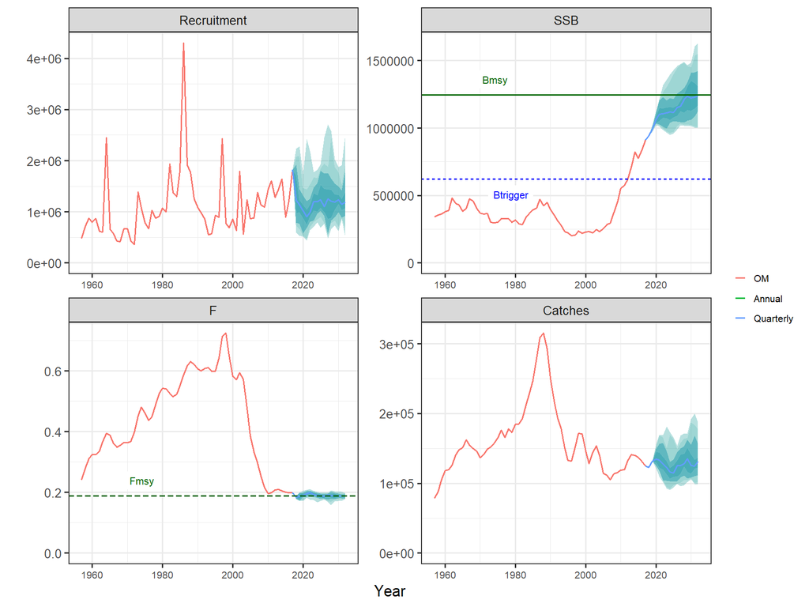

```r
rp_plot <- FLPar(Fmsy = fmsy, Bmsy = bmsy, Btrigger = 0.5 * bmsy)
plotAdvice(FLStocks(OM = window(stock(om), end = iy),
                    Annual = window(run_a@om@stock, start = iy),
                    Quarterly = window(run_q@om@stock, start = iy)),
           rpts = rp_plot)
```

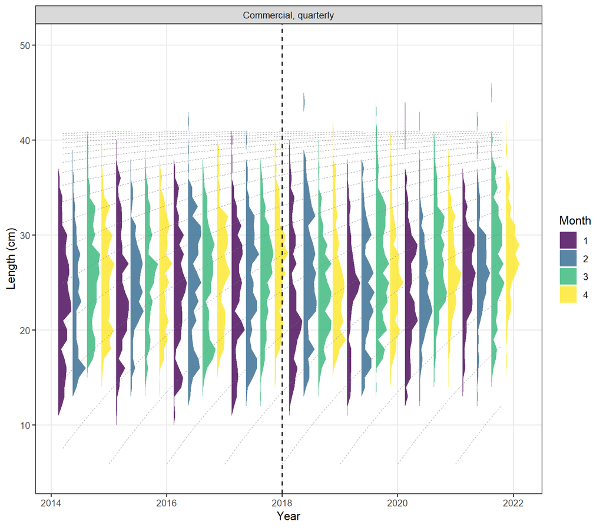

Quarterly commercial samples for iteration 1 as passed to est with season = TRUE: the last historical years and the first projection years.

```r
lfd_q <- observations(oem(run_q))$lfd$Commercial
yrs_q <- dimnames(lfd_q)$year[c(quantSums(seasonSums(iter(lfd_q, 1)))) > 0]
yrs_q <- head(yrs_q[an(yrs_q) >= iy - 3], 8)
# time runs along the (flipped) y aesthetic: dashed line = start of projection
plot_lfd_ridgeline(list(`Commercial, quarterly` = iter(lfd_q[, yrs_q], 1)), lhpar = lhpar) +
  geom_hline(yintercept = iy + 1, linetype = 2)
```

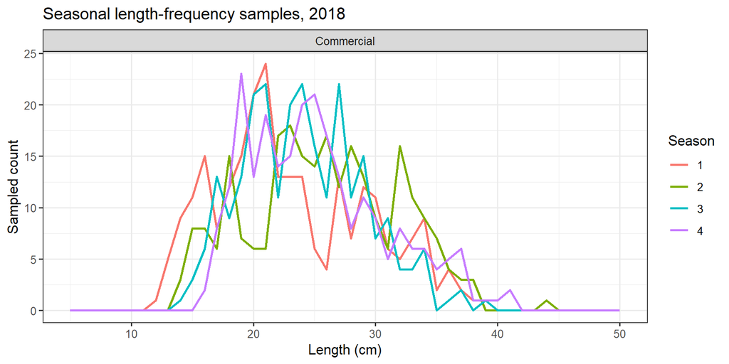

Quarterly commercial samples in the first sampled projection year (iteration 1), one line per quarter.

```r
plot_lfd_season(list(Commercial = iter(lfd_q, 1)), year = yrs_q[an(yrs_q) > iy][1])
```

# 5 Towards sex-structured and spatial stocks

The single-sex machinery extends to stocks with a populated `unit` dimension, but `unit` means two different things, and the sampling design differs:

|  | `unit.type = "gender"` (Doc 2) | `unit.type = "spatial"` (Doc 3) |
| --- | --- | --- |
| units | `"F"`, `"M"` | areas |
| growth | sex-specific `lhpar[, u]` | usually shared |
| gear selectivity-at-length | shared $s_g(l)$; $s_{g,a,u}$ differs through growth | area-specific gear sets possible |
| sampling event | **one** sample per gear from the combined catch; sexes are labels on fish | **independent** samples per area |
| ESS | `ess_age`, `ess_len` shared across sexes | per area |
| CRN streams | one per gear | one per area and gear |
| pooling for `est` | sum over units (no raising needed: sampling is proportional to catch) | raise to catch by area (`lfd.raising = TRUE`) and pool |
| length grid | must be common across sexes | common |
| within-year design | as Part II, per gear (`n_seasons`, survey `timing`) | as Part II, per area and gear |

Two choices follow for `sampling.lfd.oem()`:

- a new argument `unit.type = c("gender", "spatial")`, with the current behaviour as `"spatial"`; and
- for `"gender"`, the joint draw over (sex, age) and then (sex, length) can reuse `lfd.sim()` unchanged by stacking the sexes into one block-diagonal conditional key, season by season with `season_fraction()` computed per sex.

For the life-history parameters, an `FLPar` with a `unit` dimension (`params x unit x iter`) is preferable to `FLPars`: subsetting `lhpar[, "F"]` mirrors `stk[, , "F"]`, iterations propagate in one object, and a single argument passes through `build_gear()`. The developer notes give the details.

# 6 Appendix A: length-based utilities in FLRef

All functions are exported unless marked *internal*. Arguments in *italics* default to the gear’s settings (`gear$grid`, `gear$lhpar`).

## 6.1 A.1 Growth, length grid and keys

| Function | Purpose | Key arguments | Returns |
| --- | --- | --- | --- |
| `iALK()` | inverse age-length key $P(l\mid a,t)$, normal length-at-age around a growth curve | `params`, `model`, `age`, `cv`, `lmin`, `lmax`, `bin`, `max`, `reflen` | `FLPar` age x len |
| `len_grid()` | the single length grid (lower bin limits; last bin a plus group) | `linf`, `lmin`, `lmax_mult`, `bin` | numeric |
| `gear_ialk()` | $P(l\mid a,t)$ on a gear’s own grid, at any `timing` | `gear`, `age`, `timing`, `params` | matrix age x len |
| `condition_alk()` | capture-conditioned key $P(l\mid a,g)$ from $P(l\mid a)$ and $s_g(l)$ | `ialk_mat`, `sel_len_vec` | matrix age x len |
| `ALK()` | age-length key $P(a\mid l)$ for one sampling event | `N_a`, `iALK` | `FLPar` |
| `ALKs()` | annual keys $P(a\mid l)$ from at-age numbers and a (conditioned) inverse key | `object`, `iALK` | `FLPars` by year |

## 6.2 A.2 Selectivity and gears

| Function | Purpose | Key arguments | Returns |
| --- | --- | --- | --- |
| `sel_logistic_len()`, `sel_normal_len()`, `sel_dnormal_len()` | selectivity-at-length shapes | `L`, shape parameters | numeric |
| `sel_la()` | stand-alone selectivity-at-length and ALK-integrated selectivity-at-age | `lhpar`, `type`, shape parameters | list |
| `combine_sel_age()` | joint selectivity-at-age weighted by relative apical F | `object`, `fapic_rel` | `FLQuant` |
| `build_gear()` | gear objects: $s_g(l)$, $s_{g,a}$, $P(l\mid a,g)$, F shares, weight-at-length and sampling design (`obs`, `timing`, `n_seasons`, `ess_age`, `ess_len`) | `gear_cfg`, `lhpar`, `age`, `timing`, `fbar_range`, grid | list of gears |
| `gear_par()` | one scalar entry across gears | `om_gears`, `what` | named vector |
| `joint_sel()` | selectivity of total F implied by the gears (Fbar scale) | `om_gears` | `FLQuant` |
| `f_age_gear()` | gear F-at-age from gear Fbar trajectories | `stock`, `om_gears`, `fbar_gear` | `FLQuants` |
| `f_share_gear()` | time-varying share of total F-at-age by gear | `f_age` | `FLQuants` |
| `sel_a_seasonal_avg()` | selectivity-at-age averaged over within-year growth | `lhpar`, `sel_len`, `age`, `n_seasons` | numeric |
| `wt_a_seasonal()` | weight-at-age averaged over seasons, weighted by seasonal numbers | `n_season`, `params`, *`gear`*, `n_seasons` | `FLQuant` |

## 6.3 A.3 Catch partition and within-year allocation

| Function | Purpose | Key arguments | Returns |
| --- | --- | --- | --- |
| `catch_n_gear()` | partial Baranov catch-at-age by gear (sums to the total) | `stock`, `shares`, `years` | `FLQuants` (+ `attr(, "total")`) |
| `catch_gear()` | annual catch (weight or numbers) by gear | `catch_n`, `wt`, `type` | `FLQuants` |
| `catch_by_gear()` | relative catch by gear over a window (FLicc input) | `catch_n`, `wt`, `years`, `iter` | vector / matrix |
| `season_fraction()` | share $\pi_{a,y,s}$ of the annual catch taken in each season | `stock`, `n_seasons` | `FLQuant` with seasons |
| `seasonalize_catch_n_gear()` | seasonal gear catch-at-age from gear F-at-age | `stock`, `f_age_gear`, `n_seasons` | `FLQuants` |
| `pop_n_season()` | numbers-at-age at the start of each season | `stock`, `n_seasons` | `FLQuant` |
| `survey_n_gear()` | survey numbers-at-age at the survey timing | `stock`, `gear`, `years`, *`timing`* | `FLQuant` |

## 6.4 A.4 Sampling

| Function | Purpose | Key arguments | Returns |
| --- | --- | --- | --- |
| `ca.sim()` | multinomial catch-at-age sample (stage 1) | `object`, `ess`, `u` | `FLQuant` |
| `len.sim()` | single-stage length sample, optional gear key, several timings | `N_a`, `params`, `ess`, `timing`, `gear`, `u` | `FLQuant` |
| `lfd.sim()` | two-stage length sample (age, then length) | `object`, `gear`, *`ess_age`*, *`ess_len`*, `timing`, `u_age`, `u_len`, `scale` | `FLQuant` |
| `lfd.sim.season()` | independent two-stage sample per season, key at mid-season | `object` (seasonal), `gear`, `n_seasons`, `u_age`, `u_len`, `season` | `FLQuant` |
| `sample_lfd_gears()` | all gears of one unit: fishery (annual or within-year) and surveys; the OEM’s sampling step | `stock`, `om_gears`, `years`, `u_lfd`, `f_share`, `season` | list(`lfd`, `catch_n`) |
| `split_ess()` | exact split of a sample size among seasons | `n`, `S` | integer |
| `rmultinom_crn()` | multinomial draw from pre-generated uniforms (common random numbers) | `u`, `p` | integer counts |
| `rUnif_len()`, `rUnif_lfd()` | common random numbers for `len.sim()` / `lfd.sim()` (seasonal streams for `n_seasons > 1`) | `gear(s)`, `years`, `nsim`, `seed` | list of arrays |
| `idx.sim()` | age-based survey index with observation error | `object`, `sel`, `ess`, `sigma`, `q` | `FLIndex` |

## 6.5 A.5 From lengths to ages and raising

| Function | Purpose | Key arguments | Returns |
| --- | --- | --- | --- |
| `alk.sample()` | length-stratified otolith subsample of annual ALKs (at most `nbin` per length class) | `lfds`, `alks`, `nbin`, `n.sample` | `FLPars` (counts) |
| `applyALK()` | numbers-at-age from a length sample and annual ALKs | `lfds`, `alks` | `FLQuant` |
| `lfd_sop()` | raise a length sample to catch weight by sum of products with $W(l)$ (seasonal samples: one factor per year) | `lfd`, `wt_len`, `catch` | `FLQuant` |
| `sops()` | raise catch-at-age to the stock’s catch weight (optional error) | `object`, `stock`, `sigma` | `FLQuant` |
| `pgquant()` | set a plus group on an at-age `FLQuant` | `object`, `pg` | `FLQuant` |

## 6.6 A.6 MSE observation model

| Function | Purpose | Key arguments | Returns |
| --- | --- | --- | --- |
| `sampling.lfd.oem()` | `FLoem` method: length samples and reported catch by gear for each data year | `om_gears`, `f_share`, `season`, `lfd.raising`, `lfd.scale` | list(`stk`, `idx`, `observations`, `tracking`) |
| `lfd_obs_init()` | builds `observations$lfd` / `$catch_gear` and seeds the historical years with the OEM’s own code and random numbers | `stock`, `om_gears`, `years`, `hist_years`, `u_lfd`, `season` | list |
| `lfd_template()` | empty length-sample `FLQuant` for a gear, with the right season dimension | `gear`, `years`, `nsim`, `units`, `season` | `FLQuant` |
| `.lfd_gears_by_unit()`, `.lfd_crn_by_unit()`, `.lfd_flat_gears()` | *internal*: normalise gear and random-number lists by unit |  |  |

## 6.7 A.7 Plots

| Function | Shows |
| --- | --- |
| `plot_sel_la()` | selectivity-at-length and -at-age side by side |
| `plot_sel_age()` | one or more selectivity-at-age curves |
| `plot_condALK()` | $P(l\mid a,g)$ heat map, optionally with biological vs. conditioned mean length-at-age |
| `plot_condALK_bias()` | mean length-at-age in the population and in the catch, all gears |
| `plot_sel_a_seasonal()` | selectivity-at-age by season implied by within-year growth |
| `plot_lfd_ridgeline()` | length samples as ridgelines along time (annual or seasonal), with cohort growth lines |
| `plot_lfd_season()` | seasonal length samples for one year, by gear |
| `plot_lfd_designs()` | pooled annual composition of several sampling designs, with an expected composition |

# 7 Appendix B: notation

| Symbol | Meaning | In code |
| --- | --- | --- |
| $a, l, y, s, g$ | age, length class (lower limit), year, season, gear | dimnames `age`, `len`, `year`, `season`; gear names |
| $N_{a,y}$, $F_{a,y}$, $M_{a,y}$, $Z_{a,y}$ | numbers at 1 January, fishing, natural and total mortality | `stock.n`, `harvest`, `m` |
| $\phi_{g,a}$ | share of total F-at-age taken by gear $g$ | `gear$f_share`, `f_share_gear()` |
| $C_{g,a,y}$, $C_{g,a,y,s}$ | gear catch-at-age, annual and by season | `catch_n_gear()`, `season_fraction()` |
| $\pi_{a,y,s}$ | share of the annual catch taken in season $s$ | `season_fraction()` |
| $P(l\mid a,t)$ | biological inverse key at within-year time $t$ | `iALK()`, `gear_ialk()` |
| $s_g(l)$, $s_{g,a}$ | selectivity-at-length, ALK-integrated selectivity-at-age | `gear$sel_len`, `gear$sel_a` |
| $K_{a,l}=P(l\mid a,g)$ | capture-conditioned key | `gear$condALK`, `condition_alk()` |
| $P(a\mid l,g)$ | age-length key of the catch | `ALKs()` with `gear$condALK` |
| $n_A$, $n_L$ | stage-1 (age) and stage-2 (length) sample sizes | `ess_age`, `ess_len` |
| $W(l)=a\bar l^{\,b}$ | weight at length (bin mid-point) | `gear$wt_len` |